# 10 Estimation statistique

- Montrer tout le code
- Cacher tout le code

Auteur

Affiliation

Daniel Coulombe

Institut des Sciences, Technologies et Études Avancées d’Haïti (ISTEAH)

Date

03/04/2024

Que peut-on apprendre au sujet d’une population dont les paramètres sont inconnus, en tirant un seul échantillon aléatoire de cette population ?

Obtenir un échantillon aléatoire d’une population est une étape essentielle lorsqu’on tente de répondre à une question de recherche concernant cette population. Mais un échantillon à lui seul ne peut pas nous permettre d’atteindre ce but: il n’est qu’un reflet, souvent biaisé en raison de procédures d’échantillonnage défaillantes ou d’autres facteurs, de la population d’où il est tiré. Ce serait une erreur grave que de considérer cet échantillon comme étant une réplique exacte de la population, et d’en tirer des conclusions sans autre mesure. Néanmoins, il est souvent possible d’inférer différents paramètres de la population en l’examinant de manière appropriée.

Dans le chapitre précédent, nous avons tiré un grand nombre d’échantillons d’une population dont les paramètres étaient connus. On a pu ainsi construire et étudier certaines distributions d’échantillonnage pour différentes statistiques. Dans le présent chapitre, nous étudierons les statistiques échantillonnales (un échantillon unique) de manière à nous permettre d’estimer les paramètres correspondants au niveau de la population, ce paramètre étant inconnu. Ce type d’activité est chose courante et essentielle dans le contexte d’une recherche scientifique.

Pour les besoins des démonstrations à venir, nous utiliserons la banque de données générée par la fonction **HaitiPopGen()** (Listing 13.2).

## 10.1 Qualités des estimateurs

Un estimateur est une statistique calculée pour un échantillon aléatoire pouvant nous informer sur une propriété particulière de la population d’où provient cet échantillon. Implicitement, on souhaite que cette quantité nous fournissent des informations permettant une bonne approximation du paramètre correspondant de la population. Essentiellement, nous espérons que l’estimateur soit *non-biaisé*, *efficace* et *cohérent*. Un estimateur possédant ces qualités est *suffisant*. Pour résumer, nous souhaitons un estimateur:

- **non-biaisé**: la moyenne de la distribution d’échantillonnage de l’estimateur considéré est égale au paramètre de la population;
- **efficace**: la variance de la distribution d’échantillonnage de l’estimateur est la plus petite possible;
- **cohérente**: une augmentation de la taille de l’échantillon se traduit par une statistique s’approchant davantage du paramètre de la population;
- **suffisance**: la statistique possédant les meilleures propriétés (absence de biais, efficacité et cohérence) est la statistique suffisante.

Supposons une population normalement distribuée avec une moyenne $\mu=0$ et $\sigma=1$. Du chapitre précédent, on se souviendra que la distribution d’échantillonnage des moyennes est normale, avec $\mu_{\bar x}=\mu$ et $\sigma_{\bar x}=\sigma/ \sqrt n$. La figure Figure 10.1 illustre ces différentes qualités d’un estimateur, obtenu d’un telle population, et calculé pour des échantillons d’une certaine taille ($n$).

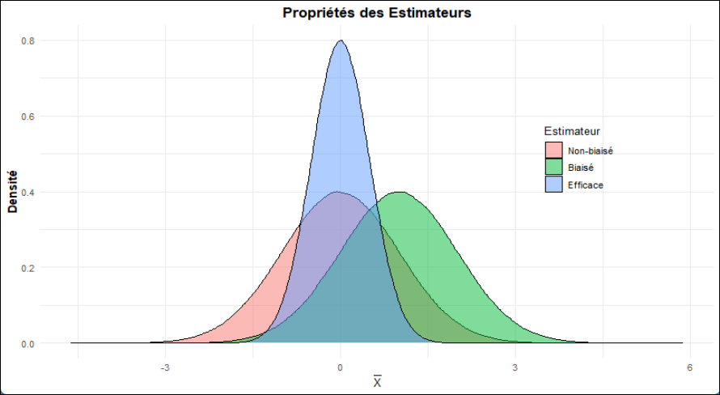

Figure 10.1: Illustration des différentes propriétés d’un estimateur

La courbe rougeâtre est non-biaisée, illustrant une distribution d’échantillonnage dont la moyenne est égale à la moyenne de la population. La courbe bleue est également non-biaisée, et elle est plus efficace que la première, produisant une dispersion moindre. Finalement, la courbe verte illustre la distribution d’échantillonnage d’un estimateur biaisé: sa moyenne se démarque de la moyenne de la population.

La dernière propriété d’un estimateur concerne sa *cohérence*, vérifiée si une augmentation de la taille de l’échantillon améliore sa précision. La Figure 10.2 illustre cette propriété, pour des échantillons de 5, 25, et 100 observations.

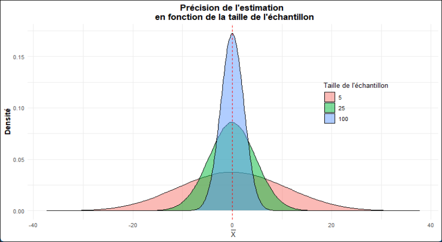

Figure 10.2: Précision d’un estimateur en fonction de la taille de l’échantillon

On observe une augmentation de la précision de l’estimateur en fonction de la taille de l’échantillon: la dispersion de la distribution d’échantillonnage décroit en fonction de $n$. On dira alors que l’estimateur est *cohérent*.

## 10.2 Estimation d’une moyenne

Au chapitre 6, on a pu obtenir la distribution des moyennes calculées pour un grand nombre d’échantillons d’une certaine taille, tous tirés de la même population. Il s’agissait de la **distribution d’échantillonnage des moyennes**.

Dans un contexte de recherche, il n’est pas possible d’obtenir autant d’échantillons: on doit composer, généralement, avec un très petit nombre d’échantillons, ou même d’un seul. Dans un tel contexte, comment peut-on obtenir la distribution d’échantillonnage dont on a besoin pour calculer les probabilités permettant de répondre à une question de recherche?

Pour répondre à cette question, considérons la distribution des indices de condition de vie (**CondxVie**) des Haïtiens vivant dans le département de l’Ouest (**DEPARTEMENT == 8**). Le code R suivant extrait de la population (**HaitiPop**), la sous-population que nous voulons étudier. La distribution au niveau de la population est affichée à la Figure 10.3.

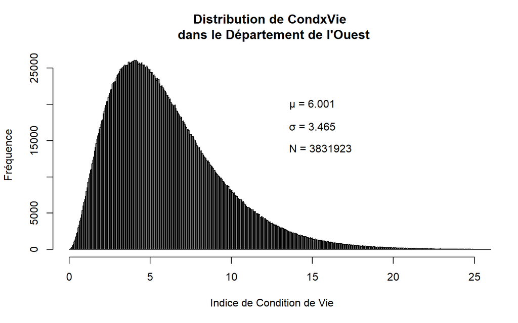

Figure 10.3: Distribution de la variable CondxVie pour les résidents du Département de l’Ouest (données fictives, simulées)

```r
xcv <- subset(HaitiPop,
              (DEPARTEMENT=="8"),
              CondxVie )
xcv <- xcv$CondxVie
#
hist(xcv,
     main="Distribution de CondxVie \n dans le Département de l'Ouest",
     breaks="FD",
     xlab="Indice de Condition de Vie",
     xlim=c(0, 25),
     ylab="Fréquence")
m1 <- mean(xcv)
s1 <- sd(xcv)
N <- length(xcv)
text(15, 20000,
     paste("\u3BC","=", round(m1, 3)))
text(15, 17000,
     paste("\u3C3","=", round(s1, 3)))
text(15.5, 14000,
     paste("N =", N))
```

Pour les besoins de la discussion, les paramètres de cette sous-population ont été calculés et affichés dans la figure Figure 10.3). Rappelons que dans le monde réel, ces éléments ne sont généralement pas connus et doivent être estimés à partir d’observations effectuées sur un échantillon.

Supposons qu’un chercheur s’intéresse à déterminer le niveau de condition de vie moyen chez cette population. Pour ce faire, les contraintes budgétaires limitent à 25 la taille de l’échantillon qu’il peut former. S’il était en mesure de tirer un très grand nombre (**Nechant = 10,000**) d’échantillons de taille *n* = 25 de la population, comme on l’a fait dans le chapitre 6, il obtiendrait la distribution d’échantillonnage représentée à la Figure 10.4).

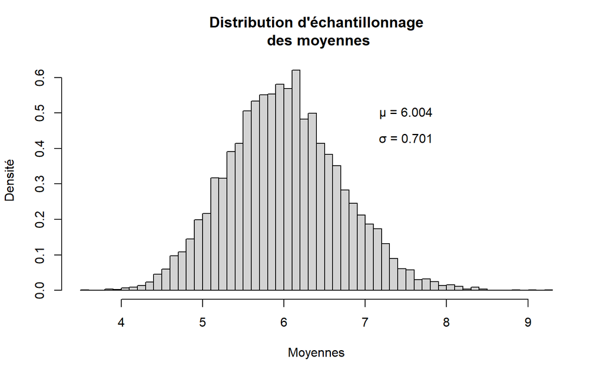

Figure 10.4: Distribution d’échantillonnage des moyennes obtenue à partir de 10,000 échantillons de taille n = 25 tirés de la population du Département de l’Ouest. La variable étudiée est CondxVie.

```r
# Simulation
Nechant <- 10000 # Nombre d'échantillons à tirer
n <- 25          # Taille de l'échantillon
xb <- replicate(Nechant,
                mean(sample(xcv, n,
                            replace=FALSE)))
# Affichage de la distribution
hist(xb,main="Distribution d'échantillonnage\n des moyennes",
     breaks="FD",
     xlab="Moyennes",
     freq=FALSE,
     ylab="Densité")
mb <- mean(xb)
sb <- sd(xb)
etd <- range(xb)
text(7.5, 0.5,
     paste("\u3BC","=", round(mb, 3)))
text(7.5, 0.43,
     paste("\u3C3","=", round(sb, 3)))
```

La moyenne de cette distribution est $\mu_{\bar X}=6.004$, et son erreur-standard est $\sigma_{\bar X}=0.701$. On constate que l’étendue des moyennes possibles couvre de 3.515 jusqu’à 9.289: en tirant un échantillon aléatoire de 25 observations de notre sous-population, on peut obtenir une moyenne qui prend n’importe quelle valeur se trouvant entre ces extrêmes, sans exclure des valeurs plus extrêmes encore! Voilà la raison pour laquelle on ne peut pas tirer de conclusion à partir d’une simple description des données obtenues d’un échantillon: on ne peut connaitre la position exacte de la moyenne obtenue pour cet échantillon, dans l’ensemble des moyennes possibles. D’autre part, les moyennes comprises entre 5 et 7 par exemple sont plus probables que les moyennes s’éloignant dans les extrémités de la distribution.

Considérons les moyennes qui occupent les 95% centraux de la distribution, les 5% restants se trouvant dans les extrémités (2.5% de chaque côté):

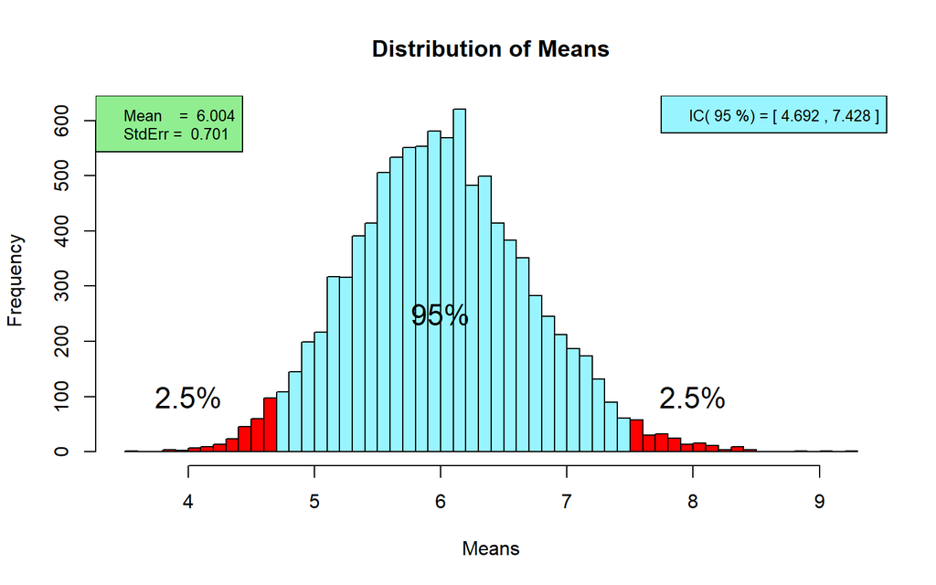

Figure 10.5: Distribution d’échantillonnage des moyennes répartie en une zone de probabilités fortes (95% central) et deux zones de probabilités faibles (5% réparti dans les deux extrémités)

```r
GraphDist(xb)
text(6,250,"95%", cex=1.5)
text(4,100,"2.5%", cex=1.5)
text(8,100,"2.5%", cex=1.5)
```

Qualifions de **probables** les moyennes situées au centre, et d’**improbables** les moyennes se trouvant dans les extrémités. Les percentiles 2.5 et 97.5 sont les frontières entre les moyennes probables et improbables, si on considère 95% comme étant le critère à utiliser.

On constate donc qu’en tirant un échantillon aléatoire de la population, un écart plus ou moins grand existera entre la vraie moyenne de la population ($\mu$) et la moyenne de l’échantillon ($\bar X$). Cet écart représente l’**erreur d’échantillonnage**: ($\bar{X}-\mu$).

Si une erreur d’échantillonnage ne dépasse pas la distance séparant la véritable moyenne de la population et la frontière entre les moyennes probables et improbables, on pourra considérer que la moyenne de l’échantillon est un reflet relativement fidèle, plausible, de la moyenne de la population. En d’autres termes, il n’y a pas de surprise à obtenir une moyenne située dans cette région. Il est toujours possible d’observer une moyenne située dans les extrémités, mais elle représente alors un événement rare.

### 10.2.1 Distribution d’échantillonnage standardisée

La notion de **score centré et réduit**, ou **score Z**, a été présentée dans le chapitre portant sur les distributions de probabilité, et utilisée à quelques reprises dans l’unité précédente. On se rappellera qu’un score Z est défini par l’Équation 10.1:

$$Z = \frac{X - \mu}{\sigma} \tag{10.1}$$

La conversion de données brutes en scores Z permet d’obtenir une distribution standardisée dont la moyenne est nulle, et l’écart-type est unitaire. Effectuer cette conversion dans le cas d’une distribution de moyennes consiste simplement à calculer les écarts entre les moyennes échantillonnales et la moyenne de la population, et les diviser ces écarts par l’écart-type de la distribution d’échantillonnage des moyennes (erreur-standard), tel qu’exprimé dans l’Équation 10.2:

$$Z=\frac{\bar X-\mu}{\sigma_{\bar X}} \tag{10.2}$$

Le code R suivant effectue la standardisation de la distribution d’échantillonnage des moyennes de CondxVie:

```r
z <- (xb - (mean(xb)))/sd(xb) # Calcul des scores Z
```

La Figure 10.6 représente la distribution des moyennes après standardisation.

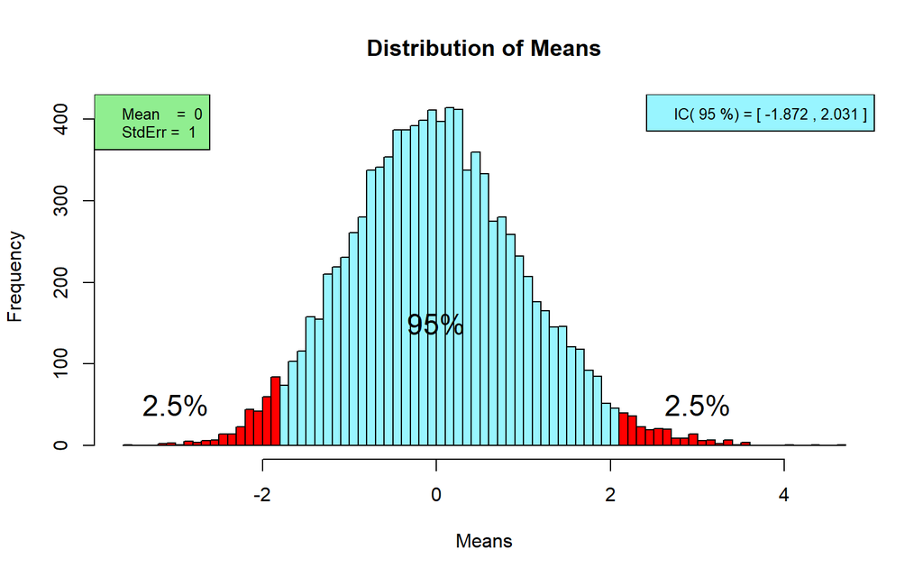

Figure 10.6: Distribution d’échantillonnage des moyennes, standardisée

```r
GraphDist(z)
text(0,150,"95%", cex=1.5)
text(-3,50,"2.5%", cex=1.5)
text(3,50,"2.5%", cex=1.5)
lim <- quantile(z, c(0.025, 0.975))
```

On note que la forme de la distribution demeure inchangée par cette standardisation. Par contre, cette distribution est maintenant centrée sur 0, et son écart-type est égal à 1. On note également que les frontières séparant le probable de l’improbable se trouvent à environ 2 erreurs-standards de la moyenne (ces limites sont respectivement -1.872 et 2.031 pour cette simulation, pour être plus précis!). Puisque la distribution est standardisée, on pourrait s’attendre à ce que ces limites puissent s’appliquer dans plusieurs situations similaires.

La différence entre une moyenne située à la limite du probable et la vraie moyenne de la population est une quantité importante en statistiques: il s’agit de la **marge d’erreur**. Cette quantité nous informe sur la distance entre l’estimation ponctuelle (statistique échantillonnale) et le paramètre de la population que l’on cherche à estimer. Par exemple, une **marge d’erreur = 3.4** nous indique que notre estimation se trouvera à au plus 3.4 unités du vrai paramètre de la population, dans une direction ou dans l’autre, avec une certaine probabilité (0.95, par exemple).

> Il faut noter que la marge d’erreur ne concerne que l’écart séparant la statistique échantillonnale du paramètre correspondant au niveau de la population. Elle ne concerne en rien les erreurs produites par un mauvais échantillonnage, ou un instrument de mesure mal calibré ou validé, ou par tout autre facteur susceptible de contaminer les données.

Quelle est l’étendue des moyennes que l’on pourrait obtenir, en toute probabilité, en répétant l’échantillonnage? Dans un premier temps, considérant les moyennes occupant le 95% central de la distribution d’échantillonnage, on peut déterminer empiriquement la marge d’erreur en calculant:

$$ME=\left ( \frac{|P_{97.5}|-|P_{2.5}|}{2}\right )$$

Pour la distribution obtenue ci-dessus, qui est standardisée de sorte que $\sigma_{\bar X}=1.0$, on trouve:

```r
ME <- diff(quantile(z, abs(c(0.025, 0.975)))) / 2
cat("Marge d'erreur = ", ME)
```

```
#> Marge d'erreur =  1.951982
```

En tirant un échantillon de *n* = 25 observations de notre population, la moyenne de cet échantillon pourrait se trouver jusqu’à 1.952 unités de la vraie moyenne de la population, 19 fois sur 20 (ou dans 95% des cas). Toute moyenne se trouvant hors de cette étendue serait jugée improbable.

### 10.2.2 Retour à la réalité!

Rappelons que le chercheur qui tente d’estimer la moyenne de la population ne dispose que d’un de ces échantillons, que l’on peut générer à l’aide du code R suivant:

```r
x <- sample(xcv, 25, replace = FALSE)
cat("Moyenne échantillonnale = ", mean(x))
```

```
#> Moyenne échantillonnale =  5.86956
```

```r
cat("Écart-type              = ", sd(x))
```

```
#> Écart-type              =  2.712776
```

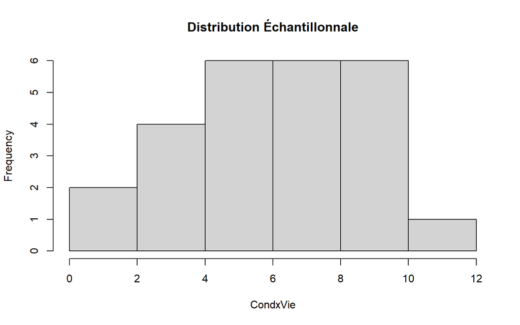

Figure 10.7: Distribution des données recueillies sur un échantillon de 25 observations

```r
hist(x,
     main = "Distribution Échantillonnale",
     xlab = "CondxVie",
     breaks = "FD")
```

La Figure 10.7 affiche la distribution des données observées.

Il obtient donc une estimation ponctuelle de la moyenne de la population: $\bar X =$ 5.87, et une estimation ponctuelle de son écart-type: $s =$ 2.713.

La marge d’erreur dans cette situation est ME = 1.952, tel que calculé antérieurement.

Le chercheur peut donc conclure que l’intervalle compris entre $\bar X \pm ME$, soit entre 3.918 et 7.822 a de bonnes chances (95%) d’inclure ou de capturer la moyenne de la population. Il aura ainsi proposé un **intervalle de confiance**, pour un **niveau de confiance** de 95%. En répétant l’expérience un nombre infini de fois, il aura raison dans 95% des cas, et se trompera dans 5% des cas. Formellement, on pourra exprimer le résultat de cette estimation par:

$C\left [3.918 \le \mu \le 7.822 \right ]=95\%$

Au final, nous avons procédé à une estimation statistique de la moyenne d’une population. On ne connait pas sa valeur exacte, mais on connait un ensemble de valeurs (un intervalle) parmi lesquelles on pourrait trouver la vraie moyenne de la population avec un degré de confiance préspécifié. On a obtenu ce résultat en supposant qu’il est possible de tirer un grand nombre d’échantillons de la population. En réalité, il y a peu de chance que cela puisse se réaliser, de sorte que l’erreur-standard des moyennes n’est toujours pas accessible. Et sans cette quantité, calculer un intervalle de confiance n’est pas du domaine du possible. Nous avons besoin d’une méthode alternative pour l’obtenir.

### 10.2.3 En résumé

Considérons maintenant comme acquis que:

1. la moyenne de la distribution des moyennes est égale à la moyenne de la population
2. l’écart-type de cette distribution (erreur-standard) est une fonction de la taille de l’échantillon: plus *n* est grand, plus l’erreur-standard des moyennes sera petite, tel que mis en évidence dans le chapitre précédent…

On peut donc utiliser la moyenne d’un échantillon en tant qu’**estimateur** de la moyenne de la population. Si l’échantillon est représentatif de la population, la moyenne de l’échantillon ne devrait pas être très éloignée de la moyenne de la population: l’erreur d’échantillonnage ne devrait pas être trop grande. Par contre, rien ne nous informe quant à la distance qui sépare ces deux moyennes! On a besoin d’information supplémentaire. La moyenne de l’échantillon ne nous fournit qu’une **estimation ponctuelle** de la moyenne de la population. Et ce n’est pas suffisant!… Il nous faut tenir compte de la dispersion des moyennes pour établir une étendue de valeurs parmi lesquelles pourrait se trouver la moyenne de la population que l’on tente d’estimer.

Étant donné un échantillon, l’estimation d’une moyenne consiste à définir une zone, au centre de la distribution d’échantillonnage des moyennes, qui a de fortes chances de capturer la moyenne de la population. La question qu’il nous faut considérer ici est de savoir en quoi consiste une *forte probabilité*?

En bref, le problème à résoudre est d’obtenir un intervalle utile, susceptible avec une probabilité connue de capturer le paramètre de la population que l’on veut estimer avec un degré satisfaisant de confiance.

Étant donné que dans un contexte de recherche nous ne disposons que d’un échantillon, le problème est de spécifier la distribution d’échantillonnage des moyennes. Des méthodes analytiques classiques existent, mais ces méthodes, qui seront discutées plus tard, reposent sur des postulats et prérequis qui souvent ne sont pas respectés. La méthode proposée ici n’implique aucun autre prérequis que la représentativité de l’échantillon.

### 10.2.4 Le ré-échantillonnage (‘*Bootstrap*’)

Supposons que dans une recherche on doive estimer la moyenne d’une population à l’aide d’un échantillon aléatoire de 25 observations. Cet échantillon est le seul à notre disposition. Sa moyenne est une estimation ponctuelle de la moyenne de la population, mais la distance qui sépare cette estimation de la véritable moyenne de la population demeure inconnue.

Le ré-échantillonnage nous permet de combler le besoin que nous avons d’obtenir un grand nombre d’échantillons et de construire la distribution d’échantillonnage. Essentiellement, la procédure se réalise en 5 étapes:

1. On obtient un échantillon de *n* observations de la population cible. On suppose que toutes les précautions ont été prises pour maximiser la représentativité de cet échantillon par rapport à la population visée!
2. De cet échantillon, on tire un grand nombre d’échantillons de la même taille (*n*), **AVEC REMISE**
3. Pour chaque échantillon, on calcule la moyenne (ou toute autre statistique d’intérêt!)
4. On dresse la distribution de ces moyennes (ou de toute autre statistique d’intérêt).
5. On obtient les percentiles correspondants à $\alpha/2$ et à $(1-\alpha/2)$, qui définissent l’intervalle de confiance recherché.

### 10.2.5 Exemple 1

On tente d’estimer la moyenne de l’indice de Condition de Vie au niveau de la population Haïtienne. On obtient un échantillon aléatoire composé de 25 individus adultes (AGE > 18). On sera satisfait si on obtient un intervalle de confiance susceptible de capturer la moyenne de la population avec un niveau de confiance de 95%. Le code R suivant génère d’abord les données échantillonnales, et calcule la moyenne et l’écart-type de l’indice de condition de vie.

```r
# Sous-population étudiée
subpop <- subset(HaitiPop, (AGE > 18), CondxVie)

# Échantillon aléatoire de n=25 observations, tiré de la population ciblée
n <- 25
xcv <- sample(subpop$CondxVie, n, replace = FALSE)
m1 <- mean(xcv)
s1 <- sd(xcv)
```

$$Estimation \; ponctuelle: \bar{X}_{CondxVie}=6.696 \qquad s_{CondxVie}=3.967$$
La procédure de ré-échantillonnage appliquée sur ces observations (100,000 échantillons) permet d’établir la distribution des moyennes, dont les percentiles $P_{2.5}$ et $P_{97.5}$ correspondent aux bornes inférieure et supérieure d’un intervalle à l’intérieur duquel on retrouve 95% des moyennes.

```r
# Ré-échantillonnage
nc <- 0.95   # Niveau de confiance
ns <- 1e+05  # Nombre de ré-échantillonnages
xb <- replicate(ns,
                mean(sample(xcv,
                            n,
                            replace = TRUE)))
# Détermination de l'intervalle de confiance
intc <- quantile(xb, c(0.5 * (1 - nc), nc + 0.5 * (1 - nc)))
```

La moyenne de l’échantillon initial est $\bar X$ = 6.696. En obtenant les percentiles 2.5 et 97.5 de la distribution des moyennes, on trouve que:

$$C\left [ 5.235 \le \mu \le 8.267 \right ] = 95\%$$

Bref, on a 95% des chances que l’intervalle s’étendant de 5.235 à 8.267 inclut la moyenne de la population. On a 5% des chances que ce ne soit pas le cas.

La Figure 10.8 représente la distribution d’échantillonnage résultante et l’intervalle que l’on vient d’obtenir.

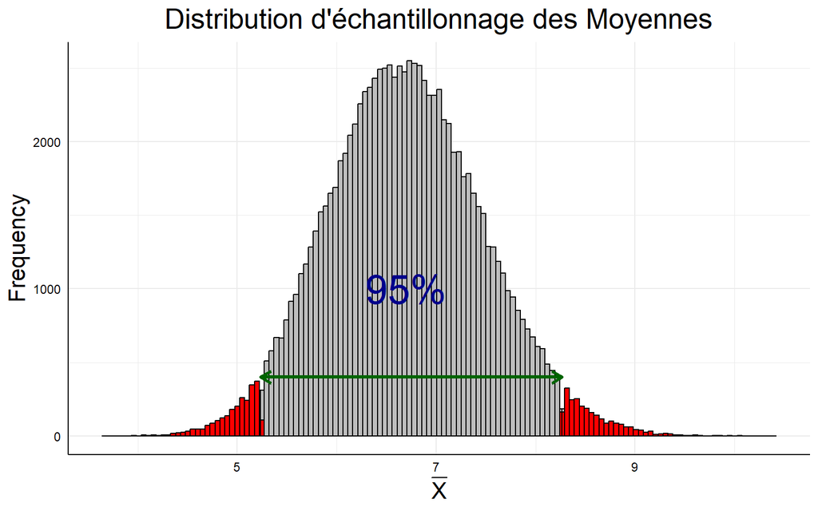

Figure 10.8: Distribution de ré-échantillonnage et intervalle de confiance

Cet intervalle porte le nom d’**intervalle de confiance** et la proportion de l’aire que cet intervalle occupe sous la distribution s’appelle **niveau de confiance**, symbolisé par $(1-\alpha)$.

Pour comparaison, quel intervalle trouverait-on en utilisant la distribution d’échantillonnage formée d’un grand nombre d’échantillons (*n*=25) effectivement tirés de la population? La Figure 10.9 en résume:

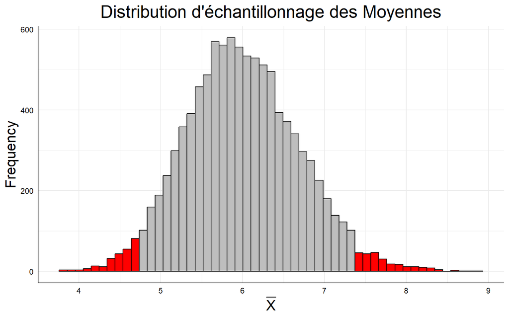

Figure 10.9: Distribution d’échantillonnage obtenue en tirant 10,000 échantillons directement d’une population

```r
set.seed(1234567)
n <- 25      # Taille de l'échantillon
nc <- 0.95   # Niveau de confiance
ns <- 10000  # Nombre d'échantillons à tirer
xdat <- subpop$CondxVie
xb <- replicate(ns,
                mean(sample(xdat, n, replace = FALSE)))
# GraphDist(xb)
intc <- quantile(xb, c(0.5 * (1 - nc), nc + 0.5 * (1 - nc)))
DistHist(xb,
         lb = intc[1],
         ub = intc[2],
         col = "red")
```

L’intervalle des valeurs probables des moyennes d’échantillons de taille $n=25$, tirés de la population est:

$$C\left [ 4.72 \le \mu \le 7.397 \right ] = 95\%$$

On constate que l’intervalle de confiance obtenu par ré-échantillonnage n’est pas très différent de celui qu’on obtiendrait dans des conditions idéales, s’il était possible de tirer un très grand nombre d’échantillons de la population étudiée. Ce résultat est très satisfaisant, pour autant que l’échantillon original soit représentatif de la population.

### 10.2.6 Anatomie d’un intervalle de confiance

La Figure 10.10 illustre la nature d’un intervalle de confiance:

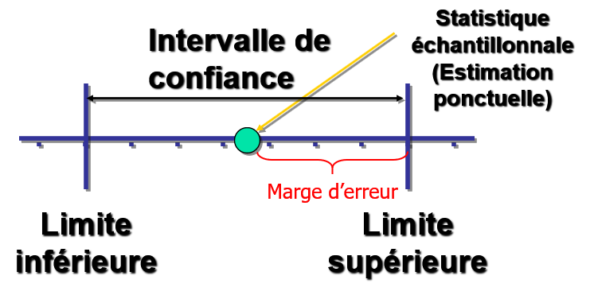

Figure 10.10: Intervalle de confiance et ses différentes composantes

La statistique échantillonnale est un estimateur du paramètre correspondant de la population. Il s’agit d’une estimation ponctuelle de ce paramètre. On sait que généralement, cet estimateur se trouvera à une certaine distance, inconnue, du paramètre de la population, ce qui constitue l’erreur d’échantillonnage:

**Erreur d’échantillonnage** = **statistique** - **paramètre**

Par exemple, dans le cas de l’estimation d’une moyenne, l’erreur d’échantillonnage sera $(\overline{X}-\mu)$. En considérant un nombre infini de moyennes échantillonnales, chacune d’elles présentant une certaine erreur d’échantillonnage, on peut déterminer les limites à l’intérieur desquelles on retrouvera une importante proportion de ces moyennes (95%, par exemple). Et cet intervalle inclura certainement le paramètre de la population. La distance qui sépare l’estimation ponctuelle de l’une ou l’autre des limites correspond à la **marge d’erreur (ME)**. Formellement, la marge d’erreur est définie par l’Équation 10.3:

$$ME=P_{(1-\alpha)}\sigma_{Stat} \tag{10.3}$$

ou $P_{(1-\alpha)}$ est le percentile de la distribution d’échantillonnage **standardisée** pour le niveau de confiance désiré, et $\sigma_{Stat}$ est l’erreur standard de cette statistique (l’écart-type de la distribution d’échantillonnage).

On peut donc définir l’intervalle de confiance par l’Équation 10.4:

$$Stat \pm ME \tag{10.4}$$

Considérant l’intervalle de confiance obtenu par ré-échantillonnage dans l’exemple 1 (section Section 10.2.5), on a:

qui correspond approximativement à:

[output not shown]

### 10.2.7 Simulation I:

La démonstration suivante nécessite un accès à Internet. Elle illustre l’ensemble de la situation que nous avons exposée dans les paragraphes précédents:

[SIMULATION d’Intervalles de Confiance](https://wise1.cgu.edu/vis/ci_creation)

Pour l’utiliser,

```
a. Choisissez la forme de la distribution de la population
b. Choisissez le niveau de confiance
c. Sélectionnez la taille de l'échantillon
d. Cliquez sur SAMPLE aussi souvent que nécessaire
```

Explorez les conséquences d’une variation dans la taille de l’échantillon, d’un changement de niveau de confiance, et/ou de la forme de la distribution de la population.

### 10.2.8 Simulation II:

La fonction **cisim()** de la librairie **PASWR2** permet de simuler des intervalles de confiance pour moyennes, variances et proportions, et d’afficher graphiquement les résultats. La Figure 10.11) reproduit les intervalles de confiance obtenus pour 100 échantillons de taille 20, et $(1-\alpha)=95\%$.

```r
set.seed(150752)
#Intervalle de confiance pour une moyenne
PASWR2::cisim(samples = 100,
              n = 20,
              parameter = 100,
              sigma = 15,
              conf.level = 0.95)
```

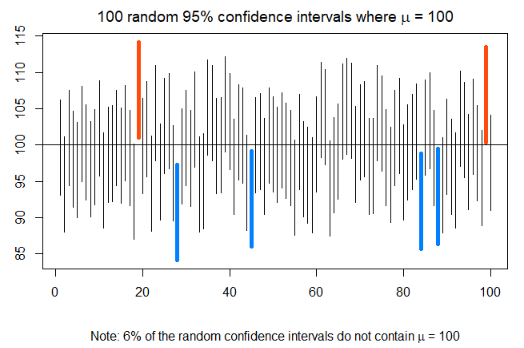

Figure 10.11: Intervalle de confiance pour une moyenne

### 10.2.9 Estimation d’une moyenne: Approche théorique, grand échantillon

Un intervalle de confiance pour une moyenne, en supposant une population normalement distribuée, se définit par l’Équation 10.5:

$$\bar X-z_{(1-\alpha/2)}\sigma_{\bar X}\le \mu \le \bar X+z_{(1-\alpha/2)}\sigma_{\bar X} \tag{10.5}$$

La quantité $z_{(1-{\alpha}/2)}$ dépend du niveau de confiance désiré. La Table 10.1 indique les percentiles, sous une distribution normale, correspondant aux niveaux de confiance fréquemment rencontrés en pratique:

Table 10.1: Percentiles correspondants aux niveaux de confiance habituels

| Niveau de confiance | Percentile |
| --- | --- |
| 90% | 1.645 |
| 95% | 1.960 |
| 99% | 2.576 |

On a déjà noté que l’erreur-standard des moyennes se définit, en théorie, par l’Équation 10.6:

$$\sigma_{\bar X}=\frac{\sigma}{\sqrt{n}} \tag{10.6}$$

Tous les éléments sont donc réunis pour permettre l’estimation d’une moyenne. Pour illustrer, générons un nouvel échantillon de *n* = 25 observations concernant l’indice de Condition de Vie chez les individus âgés de 18 ans et plus. Calculons la moyenne et l’écart-type de l’échantillon, en ajoutant l’écart-type de la population:

```r
set.seed(1234567)

subpop <- subset(HaitiPop, (AGE > 18), CondxVie)
n <- 25
xcv <- sample(subpop$CondxVie, n, replace = FALSE)
m1 <- mean(xcv)
s1 <- sd(xcv)
sp <- sd(subpop$CondxVie)
```

$$Estimation \; ponctuelle: \bar{X}_{CondxVie}=6.274 \qquad s_{CondxVie}=3.921 \qquad \sigma_{CondxVie}=3.464$$
Dès lors, on calcule l’erreur-standard des moyennes et la marge d’erreur d’estimation. L’intervalle de confiance suit naturellement:

```r
# Calcul de l'erreur-standard (connaissant l'écart-type de la population)
se <- sp / sqrt(n)

# Calcul de la marge d'erreur
ME <- qnorm(0.975)*se

# Calcul de l'intervalle de confiance (95%)
liminf <- m1 - ME
limsup <- m1 + ME
```

On trouve donc l’intervalle de confiance (95%):

$$C[4.916\le \mu \le 7.631]=95\%$$

À la limite, en tirant un nombre infini d’échantillons, l’intervalle de confiance observé devrait capturer la véritable moyenne de la population 19 fois sur 20, ou dans 95% des cas.

Ces résultats sont donc parfaitement en accord avec ceux obtenus empiriquement. Cependant, l’approche théorique suppose que la population étudiée soit distribuée normalement.

Examinons maintenant les intervalles de confiance que l’on obtiendrait en variant $(1-\alpha)$, et la taille de l’échantillon. La Table 10.2 affiche les intervalles de confiance que l’on obtiendrait pour différents niveaux de signification et différentes tailles d’échantillon:

Table 10.2: Intervalles de confiance pour différents $\alpha$ et différents $n$

|  | n = 25 | n = 50 | n = 100 | n = 200 |
| --- | --- | --- | --- | --- |
| 90% | 1.1396 | 0.8058 | 0.5698 | 0.4029 |
| 95% | 1.3580 | 0.9602 | 0.6790 | 0.4801 |
| 99% | 1.7847 | 1.2619 | 0.8923 | 0.6310 |
| Err-Std | 0.6928 | 0.4899 | 0.3464 | 0.2450 |

On note que l’erreur-standard des moyennes diminue sensiblement lorsque la taille de l’échantillon augmente. L’impact de ce changement se fait sentir dans l’importance de la marge d’erreur, qui diminue également en fonction de la taille de l’échantillon (puisque l’erreur-standard des moyennes diminue aussi en fonction de $n$). Finalement, on note que plus le niveau de confiance augmente, plus la marge d’erreur est élevée, puisque cette fois, la valeur du percentile approprié à $(1-\alpha)$ augmente en fonction de ce percentile.

La Table 10.3 présente les intervalles de confiance calculés pour différents niveaux de confiance et différents $n$, supposant un échantillon dont la moyenne est $\bar X$ = 6.274. On y note des variations conséquentes aux observations précédentes.

Table 10.3: Intervalles de confiance pour différents $(1-\alpha)$ et différents $n_s$

| Niv Conf | n = 25 Li | n = 25 Ls | n = 50 Li | n = 50 Ls | n = 100 Li | n = 100 Ls | n = 200 Li | n = 200 Ls |
| --- | --- | --- | --- | --- | --- | --- | --- | --- |
| 90% | 5.134 | 7.413 | 5.468 | 7.079 | 5.704 | 6.843 | 5.871 | 6.676 |
| 95% | 4.916 | 7.631 | 5.313 | 7.234 | 5.595 | 6.952 | 5.793 | 6.754 |
| 99% | 4.489 | 8.058 | 5.012 | 7.535 | 5.381 | 7.166 | 5.643 | 6.904 |

Dans ce tableau, Li = Limite inférieure, et Ls = Limite supérieure de l’intervalle de confiance. L’estimation ponctuelle, dans tous les cas, est la moyenne de l’échantillon, soit 6.2735.

On note en particulier que pour un niveau de confiance donné, la largeur de l’intervalle de confiance diminue en fonction de la taille de l’échantillon. Ceci est lié au fait que l’erreur-standard des moyennes diminue dans les mêmes conditions.

Finalement, la largeur de l’intervalle de confiance augmente en fonction du niveau de confiance. Rappelons que sous la distribution normale, le percentile correspondant au niveau de signification augmente en fonction de ce dernier. Par conséquent, l’intervalle de confiance en est affecté.

### 10.2.10 Estimation d’une moyenne: Approche théorique, petit échantillon

Dans le paragraphe précédent, deux conditions idéales se présentaient: nous disposions d’échantillons de grande taille, et surtout, nous connaissions l’écart-type de la population. Ces conditions réunies nous permettaient d’utiliser la distribution normale comme modèle pour le calcul des probabilités. En réalité, il est rare que nous connaissions l’écart-type de la population. En conséquence, nous n’avons d’autre choix que de considérer l’écart-type de l’échantillon pour l’évaluation de la dispersion de la population. Or, dans le chapitre précédent, il a été démontré que l’écart-type d’une population est sous-estimé lorsque la taille de l’échantillon est inférieure à 25 ou 30. Nous avons également appris que dans un tel contexte, la distribution de Student est un modèle plus approprié que la distribution normale pour obtenir les probabilités dont nous avons besoin dans la solution d’un problème.

L’estimation d’une moyenne d’une population à partir d’un échantillon de petite taille s’effectue exactement de la même manière que pour les échantillons de grande taille, sauf que l’on substitue aux percentiles de la distribution normale délimitant l’intervalle de confiance, les percentiles correspondants sous la distribution de Student, pour $dl=n-1$.

La définition de l’intervalle de confiance pour une moyenne devient alors telle qu’exprimée par l’Équation 10.7:

$$C[\bar X - t_{(dl, 1-\alpha/2)}s_{\bar X} \le \mu \le \bar X + t_{(dl, 1-\alpha/2)}s_{\bar X}]=100 \times (1-\alpha)\% \tag{10.7}$$

où la quantité $t_{(dl, 1-\alpha/2)}$ est le percentile sous la distribution de Student correspondant au niveau de confiance désiré, et $s_{\bar X}$ est l’estimation de l’erreur-standard des moyennes, à partir de l’écart-type de l’échantillon (Équation 10.8):

$$s_{\bar X}=\frac {s_x}{\sqrt{n}} \tag{10.8}$$

Pour illustrer la procédure, reprenons l’exemple précédent, concernant l’estimation de la moyenne de l’indice de condition de vie chez les adultes (âgés de 18+ ans). Dans ce cas, on obtient les percentiles requis pour la détermination de la marge d’erreur à l’aide de la fonction **qt()**, analogue à **qnorm()** que nous avons utilisée antérieurement.

```r
set.seed(1234567)
subpop <- subset(HaitiPop, (AGE > 18), CondxVie)
n <- 25
xcv <- sample(subpop$CondxVie, n, replace = FALSE)

# Calcul de l'erreur-standard (à partir de l'échantillon)
se <- s1 / sqrt(n)
```

$$Estimation \; ponctuelle: \bar{X}_{CondxVie}=6.274 \qquad s_{CondxVie}=3.921 \qquad s_{\bar{X}}=\frac{3.921}{\sqrt{25}}=0.784$$

Table 10.4: Percentiles de la distribution de Student utilisés pour le calcul de la marge d’erreur

| df | 0.4 | 0.25 | 0.1 | 0.05 | 0.025 | 0.01 | 0.005 | 0.001 |
| --- | --- | --- | --- | --- | --- | --- | --- | --- |
| 22 | -0.256 | -0.686 | -1.321 | -1.717 | -2.074 | -2.508 | -2.819 | -3.505 |
| 23 | -0.256 | -0.685 | -1.319 | -1.714 | -2.069 | -2.500 | -2.807 | -3.485 |
| 24 | -0.256 | -0.685 | -1.318 | -1.711 | -2.064 | -2.492 | -2.797 | -3.467 |
| 25 | -0.256 | -0.684 | -1.316 | -1.708 | -2.060 | -2.485 | -2.787 | -3.450 |

```r
# Calcul de la marge d'erreur
ME <- qt(0.975, df = n-1)*se
```

$$ME = t_{0.975, dl=24} \times s_{\bar{X}} = ` 2.064 \times 0.784=1.619$$

```r
liminf <- m1 - ME
limsup <- m1 + ME
```

L’intervalle de confiance recherché est donc:

$$C[4.655 \le \mu \le 7.892 ]=95\%$$

Tout ce qui a changé dans ce code R se trouve au niveau du calcul de l’erreur-standard des moyennes, calculée à partir de l’écart-type de l’échantillon plutôt que de celui de la population, et le calcul de la marge d’erreur, où le 97.5e percentile provient de la distribution de Student plutôt que de la distribution normale.

### 10.2.11 Fonction **interpret()**, librairie **interpretCI**

Les paragraphes suivants sont adaptés de la fonction **interpret()** de la librairie **interpretCI**, et présentent un exemple détaillé de la spécification d’un intervalle de confiance pour une moyenne unique, et de son interprétation.

Ce document est préparé automatiquement à l’aide des commandes R suivantes:

set.seed(12345)  
x <- rnorm(25, 47, 8)  
xresult <- meanCI(x, mu = 45)  
interpret(xresult)

#### 10.2.11.1 Problème

Un inventeur a mis au point un nouveau moteur de tondeuse à gazon économe en énergie. Dans son stock de 2000 moteurs, l'inventeur sélectionne un échantillon aléatoire simple de 25 pour les soumettre au test. Pour un seul litre d'essence, les moteurs fonctionnent en moyenne 46.99 minutes, avec un écart type de 7.56 minutes. Quel est l'intervalle de confiance à 95% pour la moyenne des durées (en minutes) de fonctionnement des moteurs? (On suppose que les temps de fonctionnement de la population des moteurs sont normalement distribués)

#### 10.2.11.2 Intervalle de confiance de la moyenne

L’approche que nous avons utilisée pour résoudre ce problème est valable lorsque les conditions suivantes sont respectées:

- La méthode d’échantillonnage doit être un échantillonnage aléatoire simple.
- La distribution d’échantillonnage doit être normalement distribuée, au moins approximativement.

Puisque les conditions ci-dessus sont satisfaites, nous pouvons utiliser l’approche suivante pour construire un intervalle de confiance de la moyenne.

#### 10.2.11.3 Données brutes

```
#> # A tibble: 10 × 1
#>    value
#>    <dbl>
#>  1  51.7
#>  2  52.7
#>  3  46.1
#>  4  43.4
#>  5  51.8
#>  6  32.5
#>  7  52.0
#>  8  44.8
#>  9  44.7
#> 10  39.6
```

#### 10.2.11.4 Statistiques observées

La taille de l’échantillon est $n= 25$; la moyenne observée pour cet échantillon est $\bar X = 46.99$ et l’écart-type est $\sigma_X = 7.56$. Nous utilisons le niveau de confiance $(1-\alpha)100\% = 95$ %.

#### 10.2.11.5 Calcul de la marge d’erreur

Puisque nous ne connaissons pas l’écart-type de la population, nous ne pouvons que calculer l’erreur-standard de la moyenne à partir de l’écart-type de l’échantillon. Comme la taille de l’échantillon est beaucoup plus petite que celle de la population, nous pouvons utiliser la formule “approximative” pour l’erreur standard, comme suit:

$$SE= \frac{s}{\sqrt{n}}$$
où **s** est l’écart-type de l’échantillon, et **n** est la taille de cet échantillon.

$$SE=\frac{7.56}{\sqrt{25}}=1.51$$

#### 10.2.11.6 Calcul de la probabilité critique ($p$):

$$p=1-\alpha/2=1-0.05/2=0.975$$

Le nombre de **degrés de liberté** ($dl$) est:

$$dl=n-1=25-1=24$$

La **valeur critique** est la statistique $t$ pour 24 degrés de liberté et une probabilité cumulative égale à 0.975. Du tableau de la distribution de Student, on trouve une valeur critique égale à 2.064.

| df | 0.4 | 0.25 | 0.1 | 0.05 | 0.025 | 0.01 | 0.005 | 0.001 |
| --- | --- | --- | --- | --- | --- | --- | --- | --- |
| 22 | -0.256 | -0.686 | -1.321 | -1.717 | -2.074 | -2.508 | -2.819 | -3.505 |
| 23 | -0.256 | -0.685 | -1.319 | -1.714 | -2.069 | -2.500 | -2.807 | -3.485 |
| 24 | -0.256 | -0.685 | -1.318 | -1.711 | -2.064 | -2.492 | -2.797 | -3.467 |
| 25 | -0.256 | -0.684 | -1.316 | -1.708 | -2.060 | -2.485 | -2.787 | -3.450 |

$$qt(p,df)=qt(0.975,24)=2.064$$

Le graphique ci-dessous illustre les zones ce la distribution correspondant à $\alpha$ et par complémentarité, l’intervalle de confiance qui se trouve au centre de cette distribution.

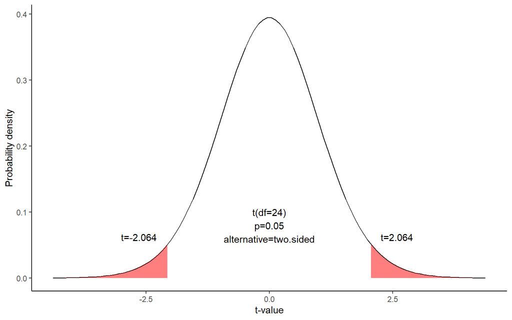

#### 10.2.11.7 Calcul de la **marge d’erreur** (ME):

$$ME=Valeur\ critique \times SE$$
$$ME=2.064 \times 1.512=3.121$$

#### 10.2.11.8 Spécification de l’intervalle de confiance:

L’étendue de l’intervalle de confiance est défini par $\bar X \pm$ME. Et notre degré d’incertitude correspond au niveau de confiance.

##### 10.2.11.8.1 Intervalle de confiance de la moyenne:

Donc, l’intervalle de confiance à 95% couvre de 43.87 à 50.11. En d’autres termes, on est confiant à 95% que la véritable moyenne de la population ($\mu$) se trouve parmi les valeurs comprises entre 43.87 et 50.11.

##### 10.2.11.8.2 Représentation graphique

On peut visualiser la situation:

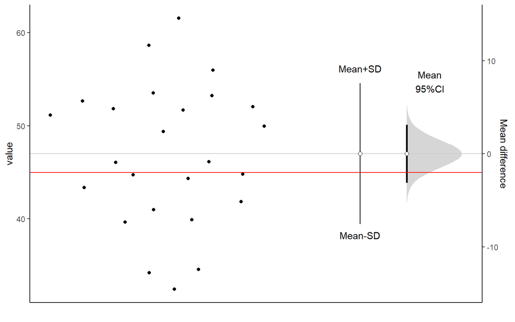

##### 10.2.11.8.3 Résultats de l’application de la fonction meanCI()

```
#>
#> call: meanCI.default(x = dat, mu = 45)
#> method: One sample t-test
#> alternative hypothesis:
#>    true mean  is not equal to  45
#>
#> Results
#> # A tibble: 1 × 7
#>   m        se     DF    lower    upper    t      p
#>   <chr>    <chr>  <chr> <chr>    <chr>    <chr>  <chr>
#> 1 46.99058 1.5122 24    43.86959 50.11157 1.3164 0.2005
```

#### 10.2.11.9 Référence

Le contenu de ce documents est adapté de StatTrek.com. Berman H.B., “AP Statistics Tutorial”, [online] Disponible à l’adresse: [stattrek.com](https://stattrek.com/estimation/confidence-interval-mean.aspx?tutorial=AP) URL[Accessed Data: 1/23/2022].

## 10.3 Estimation d’une proportion

```
#> Proportion d'appui observé = 0.19
```

On obtient une proportion de 19% d’individus favorisant le candidat à la présidence. D’une telle expérience, il est possible de calculer la probabilité qu’un certain nombre d’individus, parmi ceux composant l’échantillon, favorisent le candidat. Il s’agit simplement d’une distribution binomiale, illustrée dans la Figure 10.12:

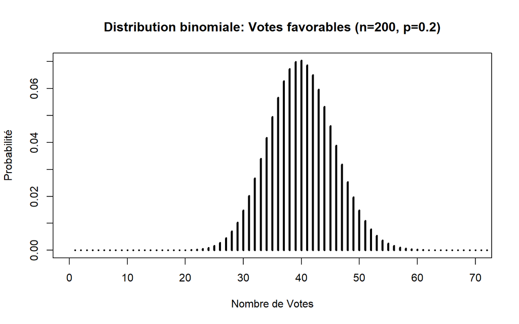

Figure 10.12: Distribution binomiale relative au nombre d’individus favorisant un candidat particulier à la présidence

On s’attend à ce que $np = 200(0.2) = 40$ électeurs favorisent le candidat. Or, la proportion observée est égale à 0.19, ce qui ne saurait nous surprendre, puisqu’il s’agit ici d’un échantillon unique qui, rappelons-le, n’est qu’un reflet, souvent distortionné, de ce qui se produit réellement au niveau de la population. Il convient donc de répéter l’expérience un grand nombre de fois pour obtenir autant de proportions de votes favorables. De ces observations, on pourra établir la distribution d’échantillonnage d’une proportion, telle qu’illustrée à la Figure 10.13:

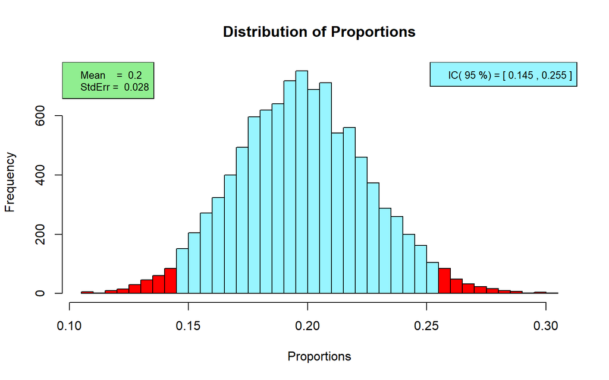

Figure 10.13: Distribution d’échantillonnage des proportions

```r
set.seed(1234567)
p <- 0.2
nc <- 0.95    # Niveau de confiance
ns <- 10000   # Nombre d'échantillons à tirer
n <- 200      # Taille de l'échantillon
xb <- replicate(ns,
                mean(sample(c(0,1),
                            n,
                            prob=c(1-p, p),
                            replace=TRUE)))
intc <- quantile(xb, c(0.5 * (1 - nc), nc + 0.5 * (1 - nc)))
GraphDist(xb,nc,"Proportions")
```

Pour un niveau de confiance fixé à 95%, en tirant un nombre infini d’échantillons de taille *n*=200 de la population, l’intervalle défini par:

$$C[0.145 \le \pi \le 0.255 ]=95\%$$

capturera la véritable proportion d’individus favorisant le candidat à la présidence, 19 fois sur 20. La marge d’erreur est égale à:

$$ME=\left ( \frac{|P_{97.5}|-|P_{2.5}|}{2}\right ) = \frac{0.255-0.145}{2}=0.055$$

En tirant un échantillon de 200 sujets de la population, la proportion de ’succès” observée sera située à au plus 5.5 points de pourcentage de la proportion réelle au niveau de la population, dans 95% des cas.

#### 10.3.0.1 Estimation d’une proportion: Ré-échantillonnage

On sait déjà que la stratégie utilisée dans les paragraphes précédents n’est pas applicable en réalité, étant donné qu’on ne peut pas tirer un nombre infini d’échantillons d’une population donnée, dans un contexte de recherche spécifique. La solution utilisée pour l’estimation d’une moyenne s’applique intégralement dans le cas présent. Pour récapituler, la procédure implique 5 étapes:

1. On obtient un échantillon de *n* observations de la population cible. On suppose que toutes les précautions ont été prises pour maximiser la représentativité de cet échantillon par rapport à la population visée!
2. De cet échantillon, on tire un grand nombre d’échantillons de la même taille (*n*), **AVEC REMISE**
3. Pour chaque échantillon, on calcule la proportion (ou toute autre statistique d’intérêt!)
4. On dresse la distribution de ces proportions.
5. On obtient les percentiles correspondants à $\alpha/2$ et à $(1-\alpha/2)$, qui définissent l’intervalle de confiance recherché.

À titre d’exemple, considérons l’appui accordé au Candidat #1, aux prochaines élections présidentielles. Les données se trouvent dans la variable **PrefPres** de l’objet **HaitiPop**. Le code R suivant extrait les données requises, à partir desquelles on tire un échantillon de 200 observations. La proportion des observations favorables au candidat #1 (**mean(xcv==1)**) est ensuite calculée:

```r
set.seed(1234567)
# Sous-population étudiée
subpop <- subset(HaitiPop, (AGE > 18), PrefPres)
#
# On obtient un échantillon aléatoire, tiré de la population ciblée
n <- 200      # Taille de l'échantillon
xcv <- sample(subpop$PrefPres, n, replace = FALSE)
cat("Estimation ponctuelle (Proportion) = ", m1 <- mean(xcv==1))
```

```
#> Estimation ponctuelle (Proportion) =  0.35
```

Pour l’échantillon obtenu, on observe que 35 % des sujets favorisent le candidat #1. Il s’agit d’une estimation ponctuelle, sujette aux fluctuations d’échantillonnage. De ces données, on doit établir un intervalle de confiance susceptible de capturer la véritable proportion au niveau de la population, avec un niveau de confiance élevé (95%, par exemple).

Puisqu’il n’est pas possible de tirer un grand nombre d’échantillons de la population, procédons à la construction de la distribution d’échantillonnage des proportions par voie de ré-échantillonnage. La Figure 10.14 en est une illustration.

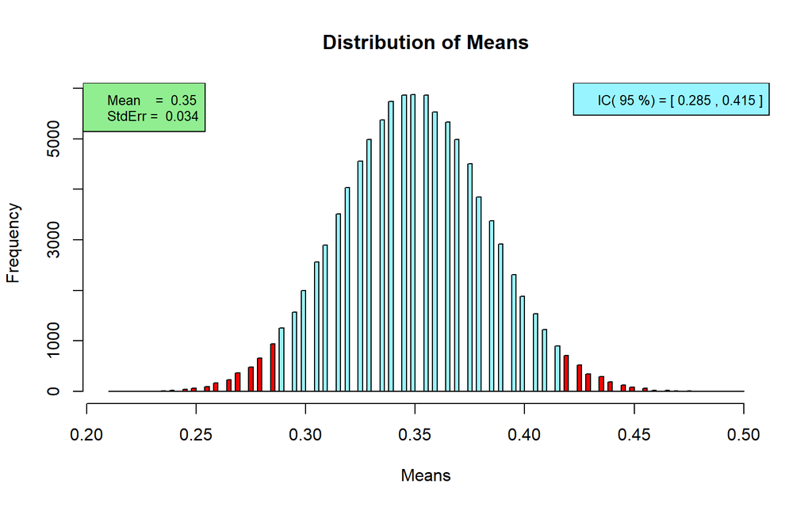

Figure 10.14: Distribution d’échantillonnage des proportions

```r
# Ré-échantillonnage
nc <- 0.95   # Niveau de confiance
ns <- 1e+05  # Nombre de ré-échantillonnages
xb <- replicate(ns,
                mean(sample(xcv, n, replace = TRUE)==1))
# Détermination de l'intervalle de confiance
intc <- quantile(xb,
                 c(0.5 * (1 - nc),
                   nc + 0.5 * (1 - nc)))
# Production du graphique
GraphDist(xb)
```

Par ré-échantillonnage, on obtient donc l’intervalle de confiance regroupant les proportions probables, comprises entre 0.285 et 0.415. En répétant l’expérience un nombre infini de fois, cet intervalle capturera la proportion de la population dans 95% des cas.

#### 10.3.0.2 Estimation d’une proportion: approche analytique (théorique)

Si les postulats liés à la distribution binomiale sont respectés et que la proportion $\pi \approx0.5$ au niveau de la population (tel qu’établi au chapitre 6), le modèle gaussien s’ajuste bien à la distribution d’échantillonnage des proportions. Dans ce cas, on peut affirmer que:

1. La distribution d’échantillonnage des proportions est gaussienne.
2. Sa moyenne est égale à $\pi$, la proportion de ‘succès’ au niveau de la population
3. Son erreur standard est définie par l’Équation 10.9:

$$\sigma_p = \sqrt{\frac{p(1-p)}{n}} \tag{10.9}$$

si la population est infinie, et par:

$$\sigma_p = \sqrt{\frac{p(1-p)}{n}}\sqrt{1-\frac{n}{N}}$$

si la population est finie.

Reprenant l’exemple précédent concernant la proportion des votes favorables à un candidat à la présidence, où l’estimation ponctuelle s’établissait à 0.35 pour un échantillon de 200 observations, on trouve:

$$\sigma_p = \sqrt{\frac{0.35(1-0.35)}{200}}=0.0337$$

On se souviendra qu’une condition requise pour la validité de la procédure est une taille d’échantillon suffisante, surtout si la proportion au niveau de la population s’éloigne vers les extrémités. Dans le cas présent, on vérifie:

$$\left [ p-3\sigma_p,~~p+3\sigma_p \right ]\subset \left [0,~~1 \right ]$$
$$\left [ 0.35-3(0.0337),~~0.35+3(0.0337) \right ]= \left [0.249,~~0.451 \right ]\subset[0, 1]$$

Le prérequis est donc respecté et on peut poursuivre.

L’intervalle de confiance pour une proportion, en utilisant la distribution gaussienne comme modèle, se définit par l’équation Équation 10.10:

$$C[p-z_{(1-\alpha/2)}\sigma_p\le\pi\le p+z_{(1-\alpha/2)}\sigma_p] = 100(1-\alpha)\% \tag{10.10}$$

où $z_{(1-\alpha/2)}$ est le percentile de la distribution gaussienne correspondant au niveau de confiance désiré. La marge d’erreur donnée par l’Équation 10.11:

$$ME=z\_{(1-\alpha/2)}\sigma_p \tag{10.11}$$

Pour l’exemple que nous traitons, pour un niveau de confiance de 95%, on obtient:

$$C[0.35-1.96(0.0337)\le\pi\le 0.35+1.96(0.0337)] =$$
$$C[0.2839\le\pi\le 0.4161)]= 95\%$$

Sous R, on obtient ce résultat en exécutant les commandes suivantes:

```r
p <- 0.35                         # proportion observée
n <- 200                          # taille de l'échantillon
nc <- 0.95                        # niveau de confiance
sep <- sqrt(p * (1-p) / n)        # erreur-standard des proportions
ME <- qnorm(nc+(1-nc)/2) * sep    # marge d'erreur
liminf <- p - ME
limsup <- p + ME
```

$$s_p=0.034 \qquad ME(95\%)=0.066$$

$$C[0.284 \le \pi \le 0.416 ]=95\%$$

En tirant un nombre infini d’échantillons de taille 200 de la population, cet intervalle capturera la véritable proportion au niveau de la population dans 95% des cas (19 fois sur 20).

### 10.3.1 Simulations d’intervalles de confiance pour proportions

Comme pour l’estimation d’une moyenne, la fonction **cisim()** de la librairie **PASWR2** permet de simuler des intervalles de confiance pour proportions:

```r
PASWR2::cisim(20, 200, 0.2, type = "Pi")
```

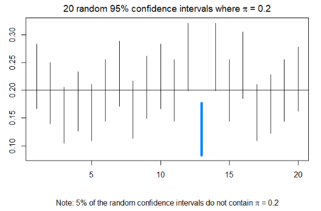

Figure 10.15: Intervalles de confiance des proportions obtenus pour 20 échantillons de 200 observations, alors que la proportion au niveau de la population est égale à 0.20

## 10.4 Estimation d’une variance

Tout ce qui a été dit concernant l’intervalle de confiance pour une moyenne peut être répété pour toute statistique que l’on peut obtenir d’un échantillon. La variance ne fait pas exception. La procédure utilisée pour estimer une moyenne ou une proportion et construire un intervalle de confiance de manière empirique est identique: on tire un échantillon aléatoire représentatif de la population étudiée, et à défaut de pouvoir effectuer cette opération un grand nombre de fois, on utilise le ré-échantillonnage pour obtenir la distribution d’échantillonnage toujours essentielle au processus d’estimation.

### 10.4.1 Estimation d’une variance: ré-échantillonnage

Supposons qu’un chercheur de l’ISTEAH s’intéresse à la variabilité des conditions de vie chez les adultes, à l’échelle du pays. Son budget de recherche lui permet un échantillon de 50 sujets âgés de 21 ans et plus. Le code R suivant définit la sous-population visée et en tire un échantillon de *n* = 50 individus, prenant note de leur indice de Condition de Vie (**CondxVie**), dont on obtient une estimation ponctuelle

```r
set.seed(150752)
subpop <- subset(HaitiPop, (AGE > 21), CondxVie)
n <- 50
xcv <- sample(subpop$CondxVie, n, replace = FALSE)
v1 <- var(xcv)
```

On obtient une estimation ponctuelle indiquant que $\sigma_{CondxVie}^2 \approx$ 7.991. Le ré-échantillonnage nous permettra d’obtenir les outils nécessaires à la construction de l’intervalle de confiance, illustré dans la Figure 10.16:

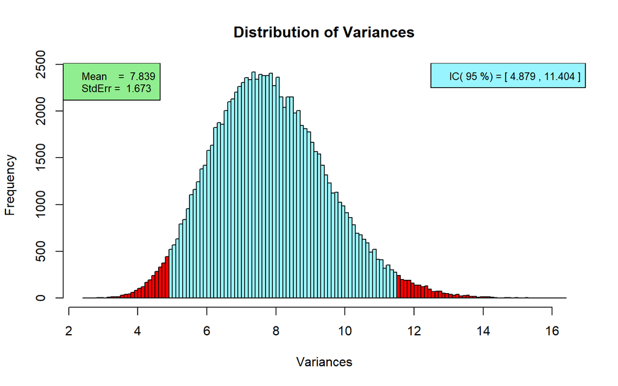

Figure 10.16: Intervalle de confiance d’une variance

```r
nc <- 0.95   # Niveau de confiance
ns <- 1e+05  # Nombre de ré-échantillonnages à effectuer
variance <- replicate(ns,
                      var(sample(xcv, n, replace = TRUE)))
# Détermination de l'intervalle de confiance
intc <- quantile(variance,
                 c(0.5 * (1 - nc),
                   nc + 0.5 * (1 - nc)))
# Affichage graphique
GraphDist(variance,nc,"Variances")
```

On trouve donc un intervalle susceptible de capturer la variance de la population dans 95% des cas, lorsqu’on répète l’expérience un nombre infini de fois:

$$C[4.879 \le \sigma^2 \le 11.404] = 95\%$$

Par curiosité, est-ce que l’intervalle de confiance que l’on vient d’obtenir parvient à capturer la variance de la population?

```r
varpop <- var(subpop$CondxVie)
cat("Variance de la population = ", varpop)
```

```
#> Variance de la population =  11.99934
```

```r
if((varpop >= intc[1]) & (varpop <= intc[2])){
  "Variance de la population capturée!"}else{
  "Variance de la population non capturée!"}
```

```
#> [1] "Variance de la population non capturée!"
```

Cet exercice de validation ne peut être réalisé sans que l’on dispose d’une estimation réaliste de la variance de la population, ce qui est justement l’objectif visé par la procédure d’estimation présentée dans les paragraphes précédents. Il illustre néanmoins que l’estimation statistique demeure faillible! Il ne faut jamais oublié qu’il existe dans toute estimation de bonnes chances de capturer le paramètre de la population, mais qu’il existe aussi des chances, plus minces il est vrai, que cette capture n’ait pas lieu!

### 10.4.2 Estimation d’une variance: Approche théorique

Rappelons que la standardisation de la variance par sa transformation en $\chi^2$ facilite grandement la construction et l’interprétation de la distribution d’échantillonnage appropriée pour l’estimation de variances de manière analytique. Reprenons l’exemple précédent dans lequel la variance dans l’indice de condition de vie pour un échantillon de 50 sujets était $s^2$ = 7.991. Sachant que:

$$\chi^2=\frac{(n-1) s^2}{\sigma^2} \tag{10.12}$$

on peut définir l’intervalle de confiance de la variance suivant l’Équation 10.13:

$$\frac{(n-1)s^2}{\chi_{dl,1-\alpha/2}^2} \le \sigma^2 \le \frac{(n-1)s^2}{\chi_{dl,\alpha/2}^2} \tag{10.13}$$

Dans cette expression, les quantités $\chi_{dl,1-\alpha/2}^2$ et $\chi_{dl,\alpha/2}^2$ représentent respectivement les percentiles délimitant l’intervalle de confiance sous la distribution du $\chi^2$. Ce sont les quantités fournies par la fonction **qchisq()**. Un échantillon de 50 sujets est utilisé pour estimer la variance dans l’indice de condition de vie. Le nombre de degrés de liberté est donc $dl=n-1=49$. Considérons un niveau de confiance de 95%. Sous R, on obtient les percentiles nécessaires et l’intervalle de confiance recherché:

```r
varx <- var(xcv)    # Variance de l'échantillon
nc <- 0.95          # Niveau de confiance
dl <- n-1           # Degrés de liberté
chi2sup <- qchisq((1-nc)/2, dl)     # Percentile alpha/2  (eg: 2.5)
chi2inf <- qchisq(nc+(1-nc)/2, dl)  # Percentile nc+alpha/2 (eg: 97.5)
intc <- c(dl*varx/chi2inf, dl*varx/chi2sup)
```

$$C[5.576 \le \sigma^2 \le 12.409 ]=95\%$$

Est-ce que cet intervalle parvient à capturer la véritable variance de la population?

```r
varpop <- var(subpop$CondxVie)
cat("Variance de la population = ", varpop)
```

```
#> Variance de la population =  11.99934
```

```r
if((varpop >= intc[1]) & (varpop <= intc[2])){
  "Variance de la population capturée!"}else{
    "Variance de la population non capturée!"}
```

```
#> [1] "Variance de la population capturée!"
```

Ce résultat, quoiqu’il ne soit pas possible de l’obtenir en pratique étant donné qu’on ne connait pas la véritable variance de la population, illustre le fait que différentes procédures statistiques peuvent produire des résultats contradictoires!

### 10.4.3 Estimation d’un écart-type

L’estimation d’un écart-type, on le devine, implique simplement la racine carrée de chacun des termes de l’Équation 10.13, ce qui donne l’Équation 10.14:

$$\sqrt{\frac{(n-1)s^2}{\chi_{dl,1-\alpha/2}^2}} \le \sigma \le \sqrt{\frac{(n-1)s^2}{\chi_{dl,\alpha/2}^2}} \tag{10.14}$$

Pour l’exemple précédent, on obtient l’intervalle de confiance pour un écart-type tel que:

```r
varx <- var(xcv)    # Variance de l'échantillon
nc <- 0.95          # Niveau de confiance
dl <- n-1           # Degrés de liberté
chi2sup <- qchisq((1-nc)/2, dl)     # Percentile alpha/2  (eg: 2.5)
chi2inf <- qchisq(nc+(1-nc)/2, dl)  # Percentile nc+alpha/2 (eg: 97.5)
intc <- sqrt(c(dl*varx/chi2inf, dl*varx/chi2sup))
```

$$C[2.361 \le \sigma \le 3.523 ]=95\%$$

### 10.4.4 Simulation d’intervalles de confiance pour variances

Le code R suivant produit une simulation d’intervalles de confiance pour variances. On tire 50 échantillons d’une population normalement distribuée avec $\mu=50$ et $\sigma=8$. Chacun de ces échantillons est ensuite soumis au ré-échantillonnage pour obtenir autant d’intervalles de confiance. Ces intervalles sont finalement affichés dans la Figure 10.17.

```r
# Intervalle de confiance d'une variance
exper <- function(x,
                  nrep = 5000,
                  n = 25,
                  mu = 50,
                  sig = 8,
                  nconf = 0.95) {
    variance <- replicate(nrep,
                          var(sample(x, n, replace = TRUE)))
    varmean <- mean(variance)
    stderr <- sd(variance)
    lims <- quantile(variance, c((1 - nconf)/2, 1 - (1 - nconf)/2))
    out <- c(varmean, stderr, lims[1], lims[2])
    return(out)
}

# set.seed(1234567)
nhit <- 0       # Nombre de capture de mu
nexp <- 50      # Nombre d'échantillons
nrep <- 5000    # Nombre de ré-échantillonnages
n <- 25         # Taille de l'échantillon
mu <- 50        # Moyenne de la population
stdev <- 8      # Écart-type de la population
variance <- stdev^2
nconf <- 0.95   # Niveau de confiance
CIdat <- matrix(NA, nrow = nexp, ncol = 4)
for (i in 1:nexp) {
    x <- rnorm(n, mu, stdev)
    CIdat[i, ] <- exper(x, nrep, n, mu, stdev, nconf)
    nhit <- nhit + ((CIdat[i, 3] <= variance) & (CIdat[i, 4] >=
        variance))
}
cat("Proportion de capture = ", nhit/nexp)
```

```
#> Proportion de capture =  0.88
```

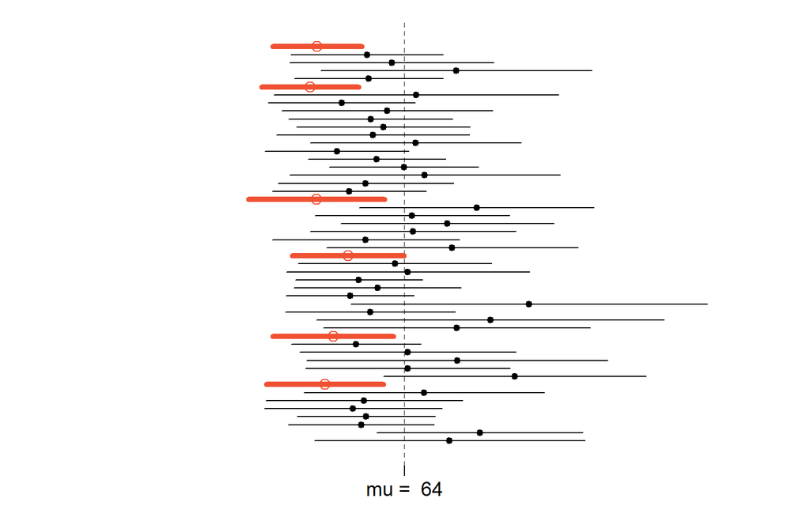

Figure 10.17: Simulation d’intervalles de confiance de variances

```r
Sample <- 1:nexp
Mean <- CIdat[, 2]
lower <- CIdat[, 3]
upper <- CIdat[, 4]
plot_ci(lower, upper, stdev^2)
```

La fonction **cisim()** de la librairie **PASWR2** permet également l’examen d’intervalles de confiance pour variances tel qu’illustré à la Figure 10.18:

```r
set.seed(150752)
#Intervalle de confiance pour une variance
cisim(100, 20, 100, 15, type = "Var")
```

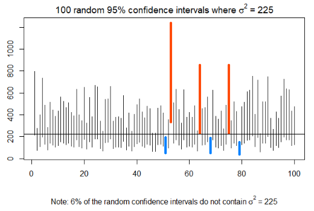

Figure 10.18: Intervalles de confiance des variances obtenus pour 100 échantillons de 20 observations, alors que la variance au niveau de la population est égale à 225

## 10.5 Estimation de la médiane

Comme pour les autres statistiques étudiées jusqu’à maintenant, le ré-échantillonnage peut s’appliquer pour l’estimation de la médiane. Une telle estimation pourrait être nécessaire lorsque la distribution de la population dévie fortement de la normalité, la médiane étant une mesure plus robuste que la moyenne dans ce cas.

### 10.5.1 Estimation de la médiane: approche empirique

Par exemple, estimons la médiane de l’indice de Criminalité pour l’ensemble de la population Haïtienne, en utilisant un échantillon de 100 sujets adultes (21+ ans):

```r
set.seed(150752)
subpop <- subset(HaitiPop, (AGE > 21), CRIMIDX)
n <- 100
xcv <- sample(subpop$CRIMIDX, n, replace = FALSE)
cat("Estimation ponctuelle (Médiane) = ", Q2s <- median(xcv))
```

```
#> Estimation ponctuelle (Médiane) =  120.2252
```

La médiane observée pour l’échantillon (estimation ponctuelle) est Q2 = 120.225, une valeur qui devrait refléter la médiane de la population, sans que l’on soit informé au sujet de la distance séparant notre estimation ponctuelle de la véritable médiane de la population. On sait qu’en principe, il suffirait de tirer un très grand nombre d’échantillons de taille *n* = 100, et pour chacun d’eux obtenir la médiane de manière à pouvoir établir sa distribution d’échantillonnage, mais en pratique, une entreprise d’une telle ampleur ne peut être menée à terme. Le ré-échantillonnage, que nous avons appliqué avec succès pour la moyenne, la variance et une proportion, peut servir ici encore. Le code R suivant permet la construction de la distribution d’échantillonnage de la médiane en procédant à 100,000 ré-échantillonnages (*n* = 100), et d’afficher cette distribution à la Figure 10.19:

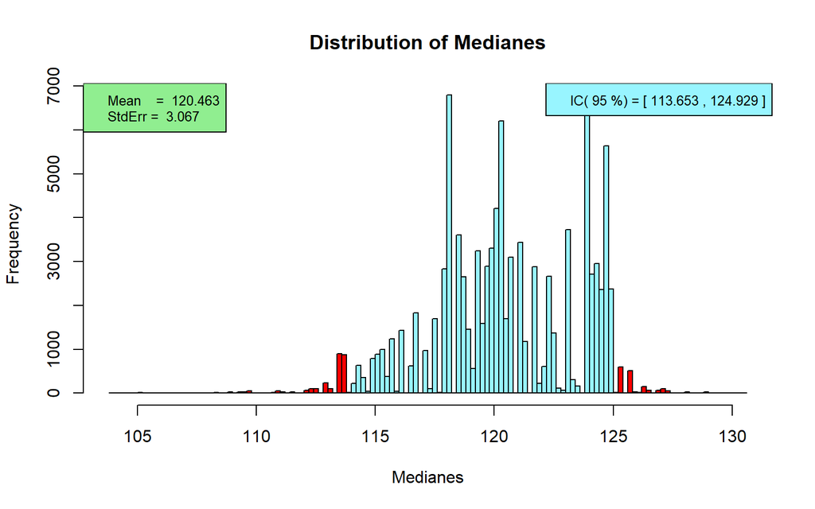

Figure 10.19: Distribution d’échantillonnage d’une médiane

```r
n <- 100
nc <- 0.95   # Niveau de confiance
ns <- 1e+05  # Nombre de ré-échantillonnages à effectuer
Q2 <- replicate(ns,
                median(sample(xcv, n, replace = TRUE)))
intc <- quantile(Q2, c(0.5 * (1 - nc), nc + 0.5 * (1 - nc)))
GraphDist(Q2, nc,"Medianes")
```

L’intervalle de confiance de la médiane obtenue à partir de notre échantillon de *n* = 100 observations est:

$$C[113.653 \le Md \le 124.929 ]=95\%$$

À la limite, pour un nombre infini d’échantillons de taille *n* = 100, cet intervalle capturera la véritable médiane de la population dans 95% des cas.

### 10.5.2 Estimation de la médiane: approche théorique

Dans le chapitre précédent, il a été établi que la distribution d’échantillonnage des médianes était au moins approximativement gaussienne, avec une erreur-standard approximativement égal à 1.2533 fois l’erreur-standard des moyennes. On peut donc formuler l’intervalle de confiance d’une médiane suivant l’Équation 10.15:

$$C[\tilde x - z_{1-\alpha /2}(1.2533)\sigma_{\bar X}\le \tilde \mu \le \tilde x + z_{1-\alpha /2}(1.2533)\sigma_{\bar X} ]=100(1-\alpha)\% \tag{10.15}$$

où $\tilde x$ représente la médiane observée pour un échantillon, et $\tilde \mu$ représente la médiane de la population. Comme toujours, $z_{1-\alpha /2}$ représente le percentile correspondant au niveau de confiance désiré, sous la distribution normale.

Reprenant l’exemple précédent, nous disposons des données suivantes:

1. Médiane de l’échantillon ($\tilde x$) = 120.225244
2. $z_{1-\alpha /2}$ = 1.96
3. $\sigma_{\bar X}$ = 2.5375147

On peut donc calculer:

```r
Md <- median(xcv)
zc <- qnorm(0.975)
sem <- sd(subpop$CRIMIDX) / sqrt(n)
semed <- 1.2533 * sem
ME <- zc * semed
intc <- c(Md-ME, Md+ME)
```

$$C[113.992 \le Md \le 126.458 ]=95\%$$

Ce résultat est en accord avec l’intervalle de confiance obtenu de manière empirique.

## 10.6 Matériel optionnel

Plusieurs outils sont disponibles dans l’environnement R pour estimer les paramètres d’une population. Dans les paragraphes précédents, les approches empirique et analytique(théorique) ont été présentées et leur efficacité démontrée, et les codes R utilisés permettaient d’en suivre le déroulement. Par contre, il est souvent plus simple et rapide d’utiliser les fonctions disponibles dans certaines librairies.

### 10.6.1 Fonction **boot.mean()**, **boot.median()**, etc.

La fonction définie ci-dessous pourra servir de modèle pour établir les distributions d’échantillonnage et les intervalles de confiance correspondant à une vaste gamme d’application.

```r
boot.mean <- function(data, num) {
  resamples <- lapply(1:num, function(i) sample(data, length(data), replace=TRUE))
  r.mean <- sapply(resamples, mean)
  std.err <- sqrt(var(r.mean))
  list(std.err=std.err, resamples=resamples, means=r.mean)
}
```

Telle que définie, cette fonction requiert deux arguments:

1. **data**: un vecteur de données observées pour un échantillon
2. **num** : le nombre de ré-échantillonnages à produire

À la sortie, on retrouve les éléments suivants:

1. **std.err**: erreur-standard (écart-type de la distribution d’échantillonnage)
2. **resamples**: ensemble des données composant chacun des échantillons
3. **means**: vecteur contenant la statistique (moyenne dans le cas présent) pour chaque échantillon

Supposons un échantillon de 50 observations tiré d’une population normalement distribuée avec $\mu=50$ et $\sigma = 8$:

```r
# Exemple d'utilisation de la fonction boot.mean)
x <- rnorm(50, 50, 8)
nrep <- 100000
b.mean <- boot.mean(x, nrep)

cat("Moyenne = ", mean(b.mean$means))
```

```
#> Moyenne =  51.88467
```

```r
cat("Erreur-Standard = ", b.mean$std.err)
```

```
#> Erreur-Standard =  0.9426546
```

```r
paste("C[", round(quantile(b.mean$means, 0.025),3),
      " \u2264 \u03BC  \u2264 ",
      round(quantile(b.mean$means, 0.975),3), "] = 95%")
```

```
#> [1] "C[ 50.049  ≤ μ  ≤  53.751 ] = 95%"
```

Pour estimer un autre paramètre, tel que la médiane, il suffit de remplacer la fonction calculant la statistique échantillonnale et le nom des variables pertinentes pour plus de clarté. Pour la médiane, on pourrait écrire:

```r
boot.median <- function(data, num) {
  resamples <- lapply(1:num, function(i) sample(data, length(data), replace=TRUE))
  r.median <- sapply(resamples, median)
  std.err <- sqrt(var(r.median))
  list(std.err=std.err, resamples=resamples, medians=r.median)
}
```

### 10.6.2 Fonction **boot()** et **boot.ci()**

La librairie **boot** permet d’obtenir des estimations de différents paramètres d’une population tout en offrant une vaste gamme d’options pertinentes. Un exemple d’utilisation de ces fonctions est reproduit ci-dessous. Les arguments de la fonction **boot** sont:

- **x**: le vecteur contenant les données
- **function(x,i) mean(x)[i]**: i est généré automatiquement et représente l’indice des différentes observations. La fonction **mean()** sera utilisée (on pourra la remplacer par **median()**, ou **var()**, ou toute autre fonction calculant une statistique échantillonnale).
- **R**: nombre de ré-échantillonnage à effectuer

La fonction **boot.ci()** reprend la sortie de **boot()** et calcule différents types d’intervalles de confiance. Les arguments de cette fonction sont:  
- **Mboot**: la sortie de boot()  
- **conf**: le niveau de confiance  
- **type**: les types d’intervalles désirés:  
a. **Classique**, fondé sur la distribution normale (gaussienne)  
b. **Basic**: Considère la nature aléatoire du paramètre estimé  
c. **perc**: utilise les percentiles de la distribution de ré-échantillonnage  
d. **BCa**: corrige pour le biais et l’asymétrie d’une distribution  
e. **Stud**: fondé sur la distribution t de Student (nécessite les estimations des variances)

Un exemple d’application de ces fonctions suit, illustrant l’estimation d’une moyenne:

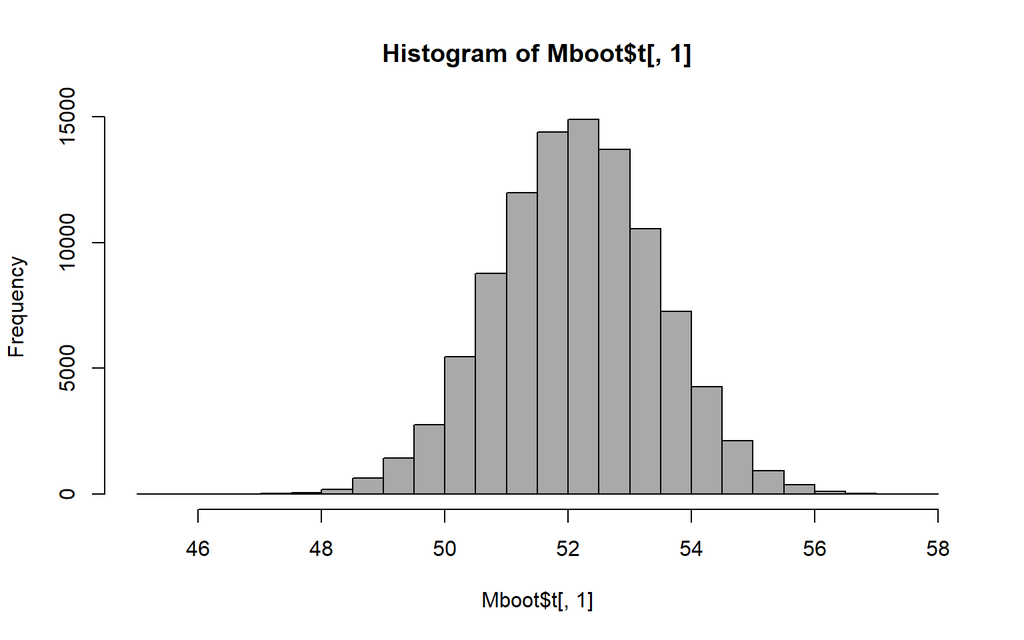

```r
if(!require(boot)){install.packages("boot")}
x <- rnorm(50, 50, 8)
Mboot = boot::boot(x,function(x,i) mean(x[i]),R=100000)
hist(Mboot$t[ ,1],
     col = "darkgray")
```

```r
Mboot
```

```
#>
#> ORDINARY NONPARAMETRIC BOOTSTRAP
#>
#>
#> Call:
#> boot::boot(data = x, statistic = function(x, i) mean(x[i]), R = 1e+05)
#>
#>
#> Bootstrap Statistics :
#>     original      bias    std. error
#> t1* 52.14725 -0.00566111    1.318659
```

La moyenne de l’échantillon est égale à 52.147, alors que celle de la distribution d’échantillonnage des moyennes est égale à 52.142. La différence entre ces deux quantités est le biais: un écart de -0.006 existe entre la moyenne de l’échantillon et la moyenne de la distribution d’échantillonnage qui, à la limite, est égale à la moyenne de la population. Finalement, l’erreur-standard de la distribution d’échantillonnage est égale à 1.3186587. Nous avons donc tout ce qui est nécessaire pour procéder à l’estimation, en faisant appel à la fonction **boot.ci()**:

```r
boot::boot.ci(Mboot,
              conf=0.95,
              type=c("norm","basic","perc","bca"))
```

```
#> BOOTSTRAP CONFIDENCE INTERVAL CALCULATIONS
#> Based on 100000 bootstrap replicates
#>
#> CALL :
#> boot::boot.ci(boot.out = Mboot, conf = 0.95, type = c("norm",
#>     "basic", "perc", "bca"))
#>
#> Intervals :
#> Level      Normal              Basic
#> 95%   (49.57, 54.74 )   (49.57, 54.75 )
#>
#> Level     Percentile            BCa
#> 95%   (49.54, 54.72 )   (49.54, 54.72 )
#> Calculations and Intervals on Original Scale
```

On obtient des intervalles de confiance de différents types. Nous avons discuté des intervalles de confiance obtenus en calculant les **percentile**s de la distribution empirique, et des intervalles construits en considérant la distribution **normal**e comme modèle. On retrouve ces deux types dans la sortie de la fonction.

### 10.6.3 Fonction **groupwiseMean/Median/Percentile**

La librairie **rcompanion** contient plusieurs fonctions susceptibles de nous intéresser. En particulier, la fonction **groupwiseMean()** et les fonctions qui y sont apparentées (**groupwiseMedian()**, et **groupwisePercentile()**) permettent d’obtenir des intervalles de confiance de différents types pour chacun des groupes représentés dans les données.

Par exemple, supposons un échantillon de 100 individus adultes (21+ ans) provenant du Département de l’Ouest. Cet échantillon est composé d’hommes et de femmes. Considérons l’indice de criminalité (CRIMIDX). Le code R suivant génère cet échantillon:

```r
set.seed(150752)
# Sous-population étudiée
subpop <- subset(HaitiPop, (AGE > 21)&(DEPARTEMENT=="8"), c(CRIMIDX, GENRE))
#
# On obtient un échantillon aléatoire, tiré de la population ciblée
n <- 100       # Taille de l'échantillon
xcv <- subpop[sample(1:nrow(subpop), n, replace = FALSE),1:2]
cat("Nombre d'hommes  = ", sum(xcv$GENRE=="M"))
```

```
#> Nombre d'hommes  =  50
```

```r
cat("Nombre de femmes = ", sum(xcv$GENRE=="F"))
```

```
#> Nombre de femmes =  50
```

Estimons la moyenne de chacun des groupes séparément, à l’aide de la fonction **groupwiseMean()**:

```r
rcompanion::groupwiseMean(
                          data=xcv,            # Source des données
                          var="CRIMIDX",       # Variable à analyser
                          group="GENRE",       # Variable de groupement
                          conf=0.95,           # Niveau de confiance
                          R=100000,            # Nombre de ré-échantillonnage
                          boot=TRUE,           # Appliquer le ré-échantillonnage
                          traditional=FALSE,   # Intervalles de confiance traditionnels
                          normal=TRUE,         # Modèle = distribution normale
                          percentile=TRUE)     # Percentiles de la distribution d'échantillonnage
```

```
#>   GENRE  n Mean Boot.mean Conf.level Normal.lower Normal.upper Percentile.lower
#> 1     F 50  120       120       0.95          115          126              115
#> 2     M 50  130       130       0.95          125          135              124
#>   Percentile.upper
#> 1              126
#> 2              135
```

Une procédure similaire permet d’obtenir les intervalles de confiance pour les médianes:

```r
groupwiseMedian(
  data=xcv,                  # Source des données
  var="CRIMIDX",             # Variable à analyser
  group="GENRE",             # Variable de groupement
  conf=0.95,                 # Niveau de confiance
  R=100000,                  # Nombre de ré-échantillonnage
  boot=TRUE,                 # Appliquer le ré-échantillonnage
  normal=TRUE,               # Modèle = distribution normale
  percentile=TRUE)           # Percentiles de la distribution d'échantillonnage
```

```
#>   GENRE  n Median Boot.median Conf.level Normal.lower Normal.upper
#> 1     F 50    127         126       0.95          122          135
#> 2     M 50    137         136       0.95          131          144
#>   Percentile.lower Percentile.upper Bca.lower Bca.upper
#> 1              118              132       117       131
#> 2              128              140       128       140
```

```r
groupwisePercentile(
  data=xcv,                  # Source des données
  var="CRIMIDX",             # Variable à analyser
  group="GENRE",             # Variable de groupement
  conf=0.95,                 # Niveau de confiance
  tau=0.25,                  # Percentile étudié
  R=100000,                  # Nombre de ré-échantillonnage
  boot=TRUE,                 # Appliquer le ré-échantillonnage
  normal=TRUE,               # Modèle = distribution normale
  percentile=TRUE)           # Percentiles de la distribution d'échantillonnage
```

```
#>   GENRE  n  tau Percentile Boot.percentile Conf.level Normal.lower Normal.upper
#> 1     F 50 0.25        104             106       0.95         90.3          115
#> 2     M 50 0.25        120             120       0.95        111.0          131
#>   Percentile.lower Percentile.upper Bca.lower Bca.upper
#> 1             97.3              120      95.4       119
#> 2            110.0              130     108.0       130
```

### 10.6.4 Fonction **BootCI()**

La fonction **BootCI()**, qui se trouve dans la librairie **DescTools**, est une autre fonction qui offre une bonne dose de versatilité. Les arguments de cette fonction sont:

1. **x**: vecteur de données à analyser (données échantillonnales)
2. **y**: vecteur contenant les données pour une seconde variable, lorsque des données bivariées sont analysées (à conserver en mémoire pour un chapitre ultérieur!)
3. **FUN**: fonction à utiliser (mean, median, var, etc)
4. bci.method: vecteur alphanumérique contenant les types d’intervalles de confiance désirés (c(“norm”, “basic”, “stud”, “perc”, “bca”)) (tous par défaut)
5. **conf.level**: niveau de confiance (0.95 par défaut)
6. **sides**: directionnalité de l’intervalle: “two.sided” par défaut, ou “left” ou “right”
7. **R**: nombre de ré-échantillonnage à effectuer

Réutilisons les données provenant du Département de l’Ouest, au sujet de l’indice de criminalité:

```r
DescTools::BootCI(xcv$CRIMIDX,
                  FUN="mean",
                  bci.method="norm",
                  conf.level=0.95,
                  sides="two.sided",
                  R=100000)
```

```
#>   "mean"   lwr.ci   upr.ci
#> 125.1087 121.2131 129.0119
```

### 10.6.5 Librairie **wBoot**

Finalement, la librairie **wBoot** nous sera utile dans les chapitres suivants, mais peut très bien servir dans les situations que nous avons rencontrées dans ce chapitre.

Jusqu’à maintenant, nous n’avons étudié qu’un seul échantillon à la fois. Dans un tel contexte, la fonction **boot.one.per()** trouve son terrain de jeu! Ses arguments sont:

1. **x**: vecteur des données à analyser (données échantillonnales)
2. **parameter**: paramètre à estimer (“mean”, “median”, etc.)
3. **conf.level**: niveau de confiance (0.95 par défaut)
4. **type**: type d’intervalle de confiance (“two-sided” (par défaut), “upper-bound” ou “lower-bound”)
5. **R** : nombre de ré-échantillonnage à effectuer (défaut = 9999)

Pour les données utilisées pour les derniers exemples, on trouve:

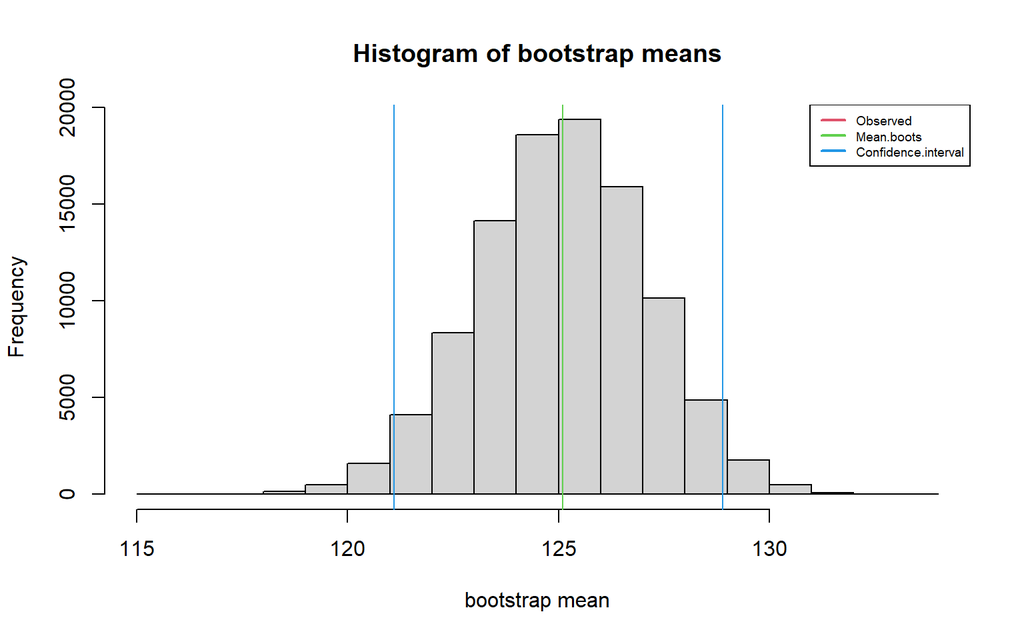

```
#>
#>
#>  RESULTS OF PERCENTILE BOOTSTRAP FOR MEAN
#>
#>     SUMMARY Variable   n Statistic Observed
#>  STATISTICS  CRIMIDX 100      mean 125.1087
#>
#>  BOOTSTRAP Replications     Mean       SE     Bias Percent.bias
#>    SUMMARY        1e+05 125.1038 2.005984 -0.00492      0.00393
#>
#>  CONFIDENCE Level      Type Confidence.interval
#>    INTERVAL   95% two-sided      (121.1, 128.9)
```

```r
b.mean <- wBoot::boot.one.per(xcv$CRIMIDX,
                              parameter=mean,
                              conf.level=0.95,
                              type="two-sided",
                              R=100000)
b.mean
```

La sortie de cette fonction est particulièrement détaillée. On y retrouve d’abord la moyenne observée au niveau de l’échantillon, dans le bloc supérieur: Moyenne = 125.1087479.

Le bloc intermédiaire contient les paramètres de la distribution d’échantillonnage obtenue par ré-échantillonnage. On y trouve que la moyenne de la distribution (à la limite égale à la moyenne de la population) est $\mu =$ 125.103827, avec une erreur-standard $\sigma_{\bar X} =$ 2.0059844.

Le bloc inférieur affiche l’intervalle de confiance pour le niveau de confiance spécifié.

La distribution d’échantillonnage est représentée par un histogramme sur lequel les limites de l’intervalle de confiance sont clairement indiquées, de même que la moyenne observée et la moyenne de la distribution d’échantillonnage.

En sauvegardant ces résultats dans une variable (**b.mean**), il est possible d’accéder à chacun des éléments, individuellement:

```r
summary(b.mean)
```

```
#>                     Length Class  Mode
#> Boot.values         100000 -none- numeric
#> Confidence.limits        2 -none- numeric
#> Header                   1 -none- character
#> Variable                 1 -none- character
#> n                        1 -none- numeric
#> Statistic                1 -none- character
#> Observed                 1 -none- numeric
#> Replications             1 -none- numeric
#> Mean                     1 -none- numeric
#> SE                       1 -none- numeric
#> Bias                     1 -none- numeric
#> Percent.bias             1 -none- numeric
#> Null                     0 -none- NULL
#> Alternative              0 -none- NULL
#> P.value                  0 -none- NULL
#> p.value                  0 -none- NULL
#> Level                    1 -none- character
#> Type                     1 -none- character
#> Confidence.interval      1 -none- character
```

Par exemple, pour accéder à l’ensemble des moyennes échantillonnales, on utilisera la commande:

```r
head(b.mean$Boot.values)
```

```
#> [1] 125.7264 121.1094 126.0136 127.9350 126.7174 126.8573
```

Il devient alors possible de poursuivre les analyses, ou produire des graphiques additionnels, en utilisant ces données.

L’ensemble de fonctions contenues dans cette librairie (**wBoot**) occupera une place importante dans les prochains chapitres.

## 10.7 Exercices

1. Examinez l’indice de propension à la criminalité (CRIMIDX) dans le département de l’Ouest (DEPARTEMENT==8) en estimant les différents paramètres de la population, en utilisant un niveau de confiance de 90%. Utilisez un échantillon de 50 sujets.
   1. Estimez la moyenne:

```r
# Population ciblée
subpop <- subset(HaitiPop,
                 (DEPARTEMENT == 8) & (AGE >= 15),
                 select = CRIMIDX)

n <- 50  # Taille de l'échantillon
xcv <- sample(subpop$CRIMIDX, n, replace = FALSE)
# Ré-échantillonnage
nc <- 0.9  # Niveau de confiance
ns <- 1e+05  # Nombre de ré-échantillonnages
xb <- replicate(ns, mean(sample(xcv, n, replace = TRUE)))
#
cat("Moyenne         = ", mean(xb))
```

```
#> Moyenne         =  134.1207
```

```r
cat("Erreur Standard = ", sd(xb))
```

```
#> Erreur Standard =  2.991597
```

```r
# Détermination de l'intervalle de confiance
intc <- quantile(xb, c(0.5 * (1 - nc), nc + 0.5 * (1 - nc)))
cat("C[",round(intc[1],3),"< μ < ",round(intc[2],3),"] = ",100*nc,"%")
```

```
#> C[ 129.086 < μ <  138.943 ] =  90 %
```

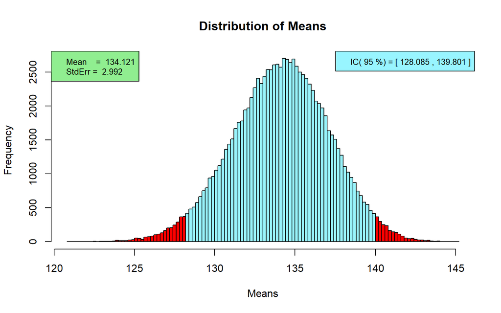

```r
# Distribution des Moyennes
GraphDist(xb)
```

2. Estimez la médiane:

```r
# Population ciblée
# subpop <- subset(HaitiPop,
#                 (DEPARTEMENT==8)&(AGE>=15),
#                 select=CRIMIDX)

n <- 50  # Taille de l'échantillon
xcv <- sample(subpop$CRIMIDX, n, replace = FALSE)
# Ré-échantillonnage
nc <- 0.9  # Niveau de confiance
ns <- 1e+05  # Nombre de ré-échantillonnages
xb <- replicate(ns, median(sample(xcv, n, replace = TRUE)))
#
cat("Moyenne         = ", mean(xb))
```

```
#> Moyenne         =  132.2367
```

```r
cat("Erreur Standard = ", sd(xb))
```

```
#> Erreur Standard =  3.15362
```

```r
# Détermination de l'intervalle de confiance
intc <- quantile(xb, c(0.5 * (1 - nc), nc + 0.5 * (1 - nc)))
cat("C[",round(intc[1],3),
    "< Médiane < ",
    round(intc[2],3),"] = ",100*nc,"%")
```

```
#> C[ 127.702 < Médiane <  137.395 ] =  90 %
```

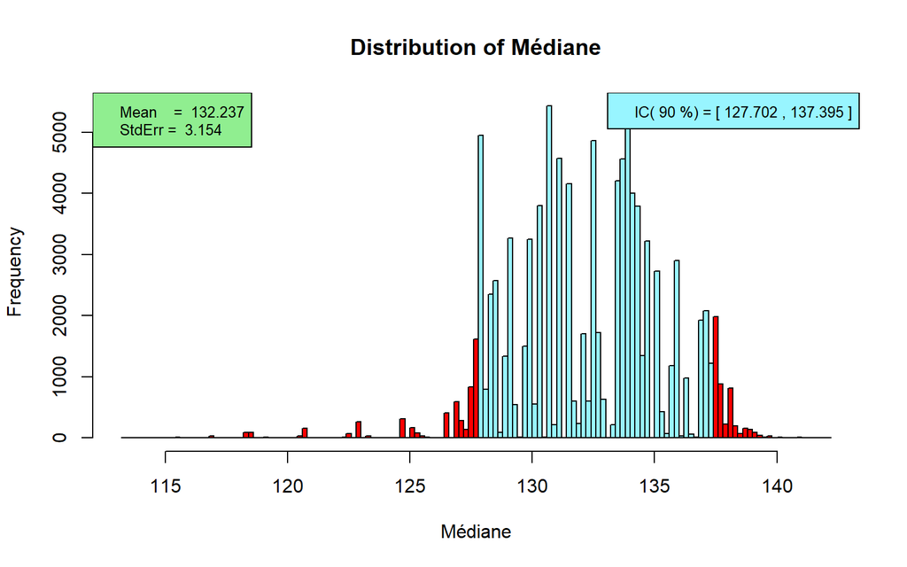

```r
# Distribution des Médianes
GraphDist(xb,nc,"Médiane")
```

3. Estimez la proportion des individus dont l’indice de criminalité est supérieur à 140.

```r
# Population ciblée
# subpop <- subset(HaitiPop,
#                 (DEPARTEMENT==8)&(AGE>=15),
#                 select=CRIMIDX)

n <- 50  # Taille de l'échantillon
xcv <- sample(subpop$CRIMIDX, n, replace = FALSE)
# Ré-échantillonnage
nc <- 0.9  # Niveau de confiance
ns <- 1e+05  # Nombre de ré-échantillonnages
xb <- replicate(ns, sum(sample(xcv, n, replace = TRUE) > 140)/n)
#
cat("Moyenne         = ", mean(xb))
```

```
#> Moyenne         =  0.4201432
```

```r
cat("Erreur Standard = ", sd(xb))
```

```
#> Erreur Standard =  0.06974987
```

```r
# Détermination de l'intervalle de confiance
intc <- quantile(xb, c(0.5 * (1 - nc), nc + 0.5 * (1 - nc)))
cat("C[", round(intc[1], 3),
    "< P(CRIMIDX > 140) < ",
    round(intc[2],3),
    "] = ", 100 * nc, "%")
```

```
#> C[ 0.3 < P(CRIMIDX > 140) <  0.54 ] =  90 %
```

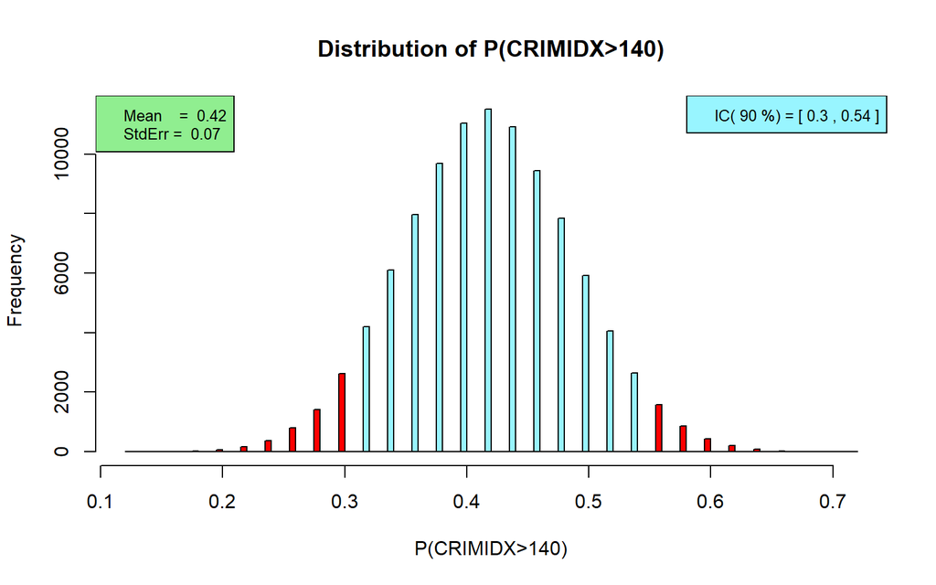

```r
# Distribution des Proportions (P(CRIMIDX)>140)
GraphDist(xb,nc,"P(CRIMIDX>140)")
```

4. Estimez le rapport entre l’écart-type et la moyenne, multiplié par 100: $CV = \frac{\sigma}{\mu}\times 100$

```r
# Population ciblée
# subpop <- subset(HaitiPop,
#                 (DEPARTEMENT==8)&(AGE>=15),
#                 select=CRIMIDX)

n <- 50  # Taille de l'échantillon
xcv <- sample(subpop$CRIMIDX, n, replace = FALSE)
# Ré-échantillonnage
nc <- 0.9  # Niveau de confiance
ns <- 1e+05  # Nombre de ré-échantillonnage
cv <- vector()

for (i in 1:ns) {
    x <- sample(xcv, n, replace = TRUE)
    cv[i] <- sd(x)/mean(x) * 100
}

#
cat("Moyenne         = ", mean(cv))
```

```
#> Moyenne         =  16.5941
```

```r
cat("Erreur Standard = ", sd(cv))
```

```
#> Erreur Standard =  1.626435
```

```r
# Détermination de l'intervalle de confiance
intc <- quantile(cv, c(0.5 * (1 - nc), nc + 0.5 * (1 - nc)))
cat("C[", round(intc[1], 3),
    "< CV < ",
    round(intc[2], 3), "] = ",
    100 * nc, "%")
```

```
#> C[ 13.881 < CV <  19.234 ] =  90 %
```

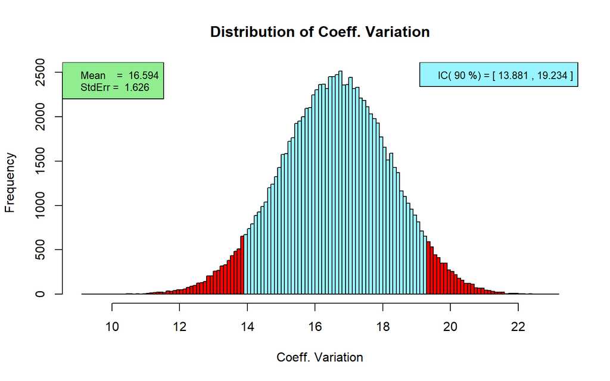

```r
# Distribution des Coefficients de Variation
GraphDist(cv,nc,"Coeff. Variation")
```

5. Estimez le 75e percentile.

```r
# Population ciblée
# subpop <- subset(HaitiPop,
#                 (DEPARTEMENT==8)&(AGE>=15),
#                 select=CRIMIDX)

n <- 50  # Taille de l'échantillon
xcv <- sample(subpop$CRIMIDX, n, replace = FALSE)
# Ré-échantillonnage
nc <- 0.9  # Niveau de confiance
ns <- 1e+05  # Nombre de ré-échantillonnages
p75 <- replicate(ns, quantile(sample(xcv, n, replace = TRUE), 0.75))

cat("Moyenne         = ", mean(p75))
```

```
#> Moyenne         =  148.2511
```

```r
cat("Erreur Standard = ", sd(p75))
```

```
#> Erreur Standard =  2.365894
```

```r
# Détermination de l'intervalle de confiance
intc <- quantile(p75, c(0.5 * (1 - nc), nc + 0.5 * (1 - nc)))
cat("C[", round(intc[1], 3),
    "< P75 < ",
    round(intc[2], 3), "] = ",
    100 * nc, "%")
```

```
#> C[ 144.112 < P75 <  150.24 ] =  90 %
```

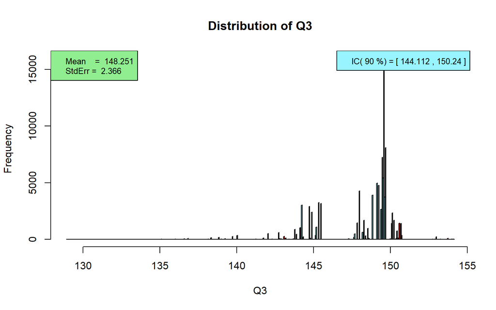

```r
# Distribution des Q3
GraphDist(p75,nc,"Q3")
```

6. Répétez ces estimations, et utilisant des échantillons de *n* = 500 observations. Que remarquez-vous?

```
a. Estimez la moyenne:
```

```r
# Population ciblée
# subpop <- subset(HaitiPop,
#                 (DEPARTEMENT==8)&(AGE>=15),
#                 select=CRIMIDX)

n <- 500  # Taille de l'échantillon
xcv <- sample(subpop$CRIMIDX, n, replace = FALSE)
# Ré-échantillonnage
nc <- 0.9  # Niveau de confiance
ns <- 1e+05  # Nombre de ré-échantillonnages
xb <- replicate(ns, mean(sample(xcv, n, replace = TRUE)))

cat("Moyenne         = ", mean(xb))
```

```
#> Moyenne         =  132.6609
```

```r
cat("Erreur Standard = ", sd(xb))
```

```
#> Erreur Standard =  0.9142754
```

```r
# Détermination de l'intervalle de confiance
intc <- quantile(xb, c(0.5 * (1 - nc), nc + 0.5 * (1 - nc)))
cat("C[",round(intc[1],3),
    "< μ < ",
    round(intc[2],3),"] = ",100*nc,"%")
```

```
#> C[ 131.149 < μ <  134.157 ] =  90 %
```

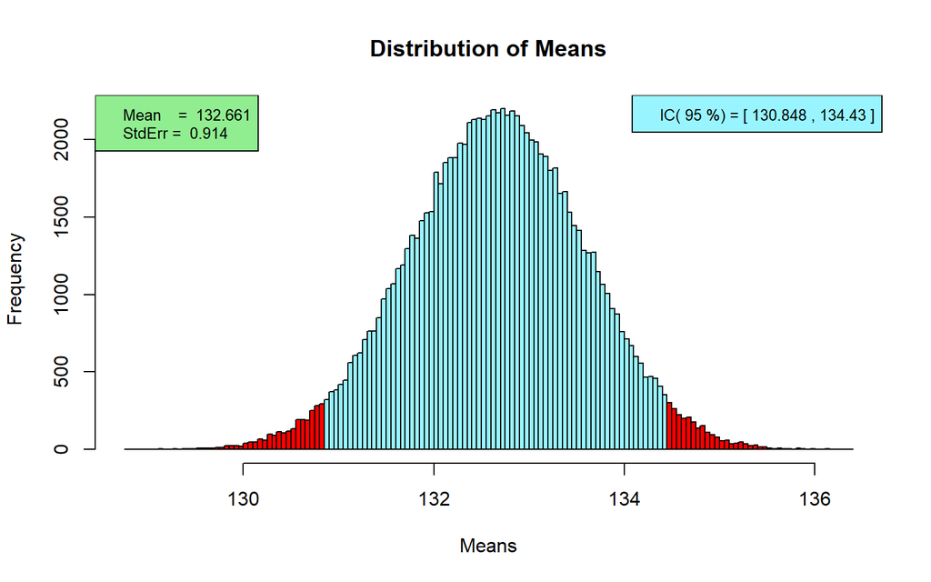

```r
# Distribution des Moyennes
GraphDist(xb)
```

2. Estimez la médiane:

```r
# Population ciblée
# subpop <- subset(HaitiPop,
#                 (DEPARTEMENT==8)&(AGE>=15),
#                 select=CRIMIDX)

n <- 500  # Taille de l'échantillon
xcv <- sample(subpop$CRIMIDX, n, replace = FALSE)
# Ré-échantillonnage
nc <- 0.9  # Niveau de confiance
ns <- 1e+05  # Nombre de ré-échantillonnages
xb <- replicate(ns, median(sample(xcv, n, replace = TRUE)))
#
cat("Moyenne         = ", mean(xb))
```

```
#> Moyenne         =  136.9965
```

```r
cat("Erreur Standard = ", sd(xb))
```

```
#> Erreur Standard =  1.373067
```

```r
# Détermination de l'intervalle de confiance
intc <- quantile(xb, c(0.5 * (1 - nc), nc + 0.5 * (1 - nc)))
cat("C[",round(intc[1],3),
    "< Médiane < ",
    round(intc[2],3),"] = ",100*nc,"%")
```

```
#> C[ 134.644 < Médiane <  139.206 ] =  90 %
```

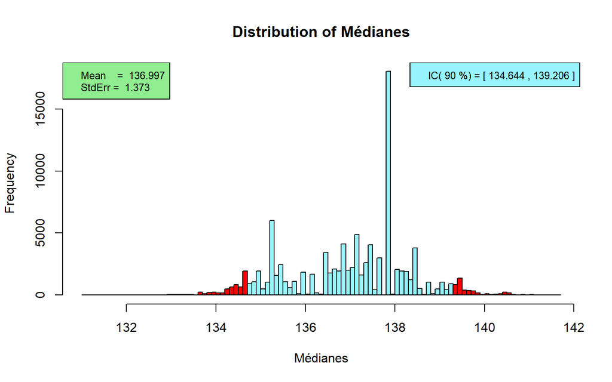

```r
# Distribution des Médianes
GraphDist(xb,nc,"Médianes")
```

3. Estimez la proportion des individus dont l’indice de criminalité est supérieur à 140.

```r
# Population ciblée
# subpop <- subset(HaitiPop,
#                 (DEPARTEMENT==8)&(AGE>=15),
#                 select=CRIMIDX)

n <- 500  # Taille de l'échantillon
xcv <- sample(subpop$CRIMIDX, n, replace = FALSE)
# Ré-échantillonnage
nc <- 0.9  # Niveau de confiance
ns <- 1e+05  # Nombre de ré-échantillonnages
# x = sum(sample(xcv,n,replace=TRUE)>140)/n
xb <- replicate(ns, sum(sample(xcv, n, replace = TRUE) > 140)/n)

cat("Moyenne         = ", mean(xb))
```

```
#> Moyenne         =  0.4039191
```

```r
cat("Erreur Standard = ", sd(xb))
```

```
#> Erreur Standard =  0.02204533
```

```r
# Détermination de l'intervalle de confiance
intc <- quantile(xb, c(0.5 * (1 - nc), nc + 0.5 * (1 - nc)))
cat("C[", round(intc[1], 3),
    "< P(CRIMIDX > 140) < ",
    round(intc[2],3), "] = ", 100 * nc, "%")
```

```
#> C[ 0.368 < P(CRIMIDX > 140) <  0.44 ] =  90 %
```

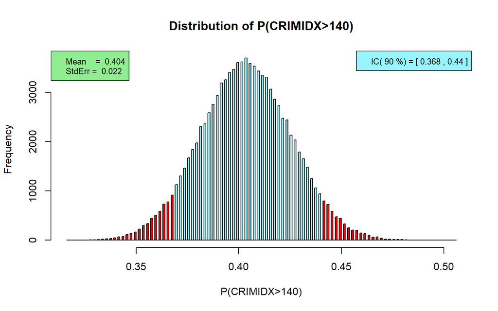

```r
# Distribution des Proportions (P(CRIMIDX)>140)
GraphDist(xb,nc,"P(CRIMIDX>140)")
```

4. Estimez le rapport entre l’écart-type et la moyenne, multiplié par 100: $CV = \frac{\sigma}{\mu}\times 100$

```r
# Population ciblée
# subpop <- subset(HaitiPop,
#                 (DEPARTEMENT==8)&(AGE>=15),
#                 select=CRIMIDX)

n <- 500  # Taille de l'échantillon
xcv <- sample(subpop$CRIMIDX, n, replace = FALSE)
# Ré-échantillonnage
nc <- 0.9  # Niveau de confiance
ns <- 1e+05  # Nombre de ré-échantillonnages
cv <- vector()

for (i in 1:ns) {
    x <- sample(xcv, n, replace = TRUE)
    cv[i] <- sd(x)/mean(x) * 100
}

#
cat("Moyenne         = ", mean(cv))
```

```
#> Moyenne         =  15.99411
```